# Duck Phyloaccc

X

X

X

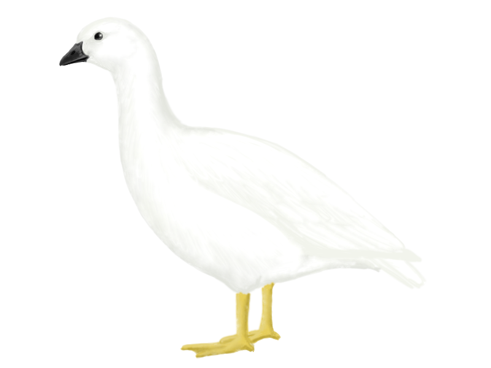

Chloephaga hybrida

Kelp Goose

MCZ:Orn:340225

X

X

X

X

X

X

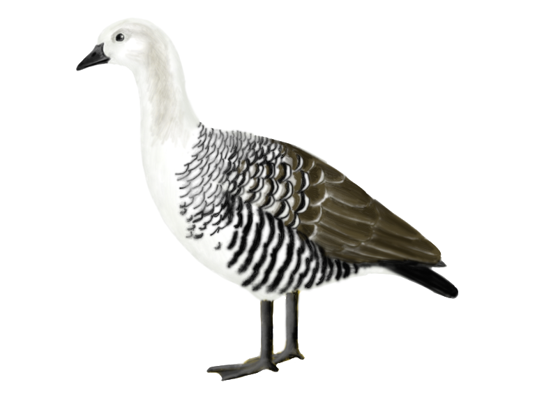

Chloephaga picta

Upland Goose

MCZ:Orn:342847

X

X

X

X

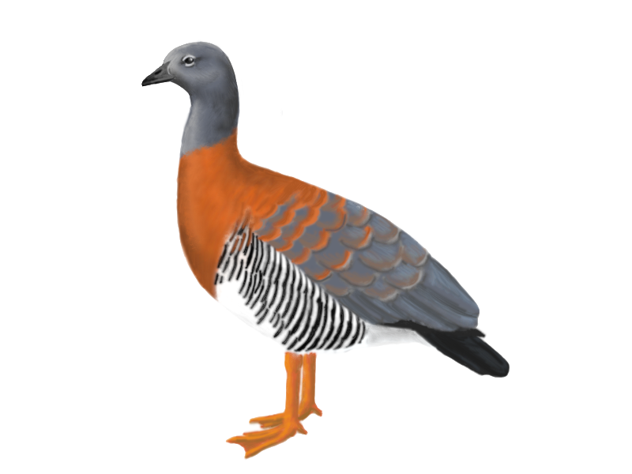

Chloephaga poliocephala

Ashy-headed Goose

NHMUK:Zoo:S/1963.10.1

X

X

X

X

X

X

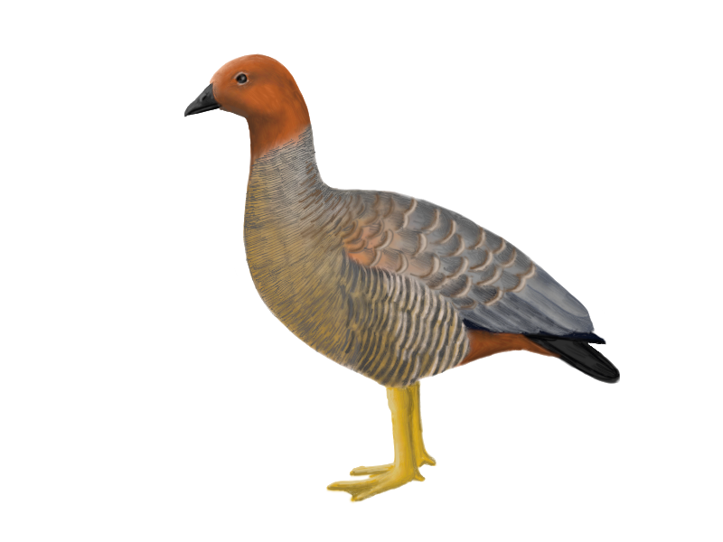

Chloephaga rubidiceps

Ruddy-headed Goose

MCZ:Orn:343209

X

X

X

X

X

X

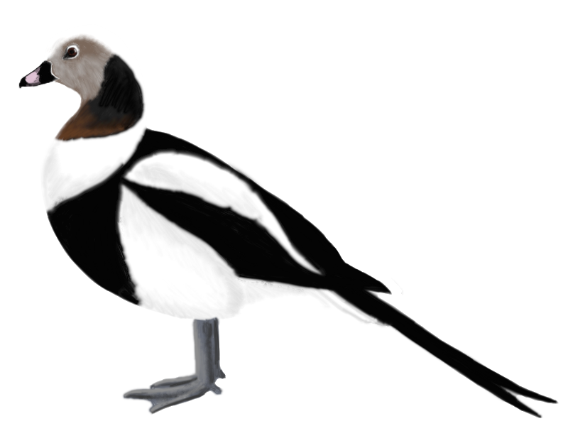

Clangula hyemalis

Long-tailed Duck

MCZ:Orn:346497

GCA_029619115.1

X

X

X

X

X

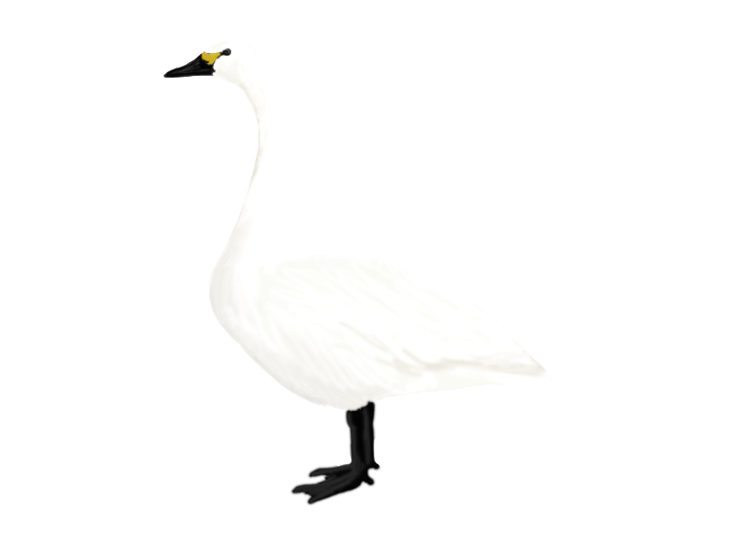

Cygnus columbianus

Tundra Swan

MCZ:Orn:343048

X

X

X

X

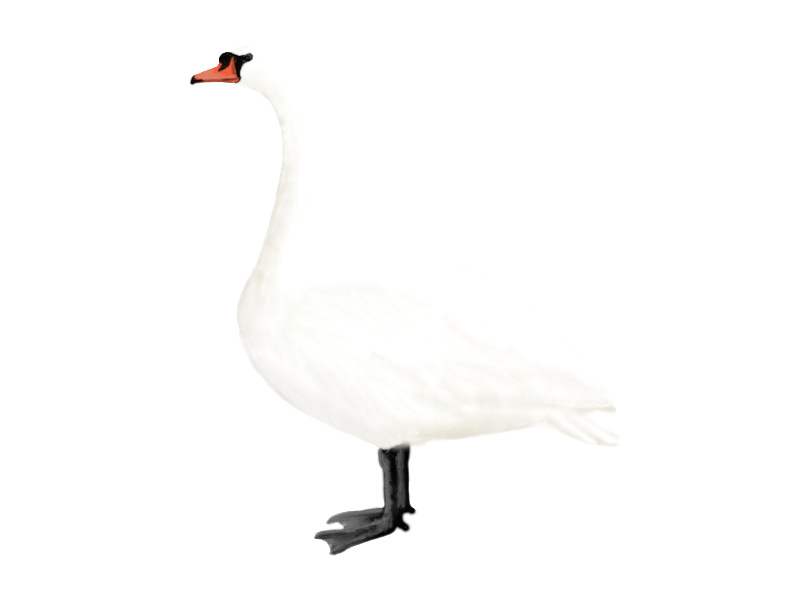

Cygnus olor

Mute Swan

NHMUK:Zoo:1854.6.25.2

GCA_009769625.2

X

X

X

X

X

X

X

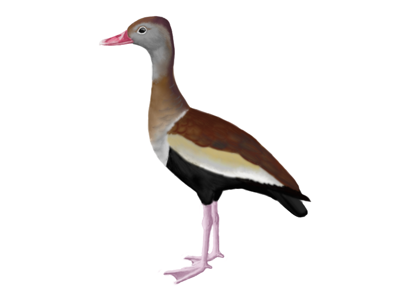

Dendrocygna autumnalis

Black-bellied Whistling-Duck

MCZ:Orn:335880

X

X

X

X

X

X

X

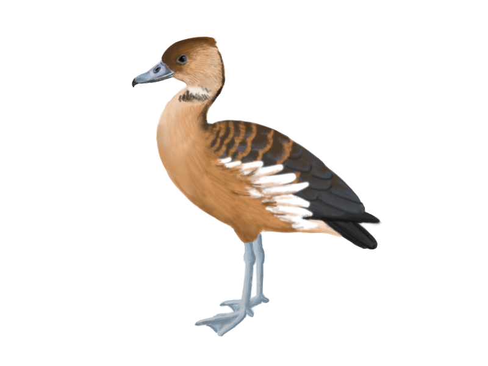

Dendrocygna bicolor

Fulvous Whistling-Duck

MCZ:Orn:347071

X

X

X

X

X

X

X

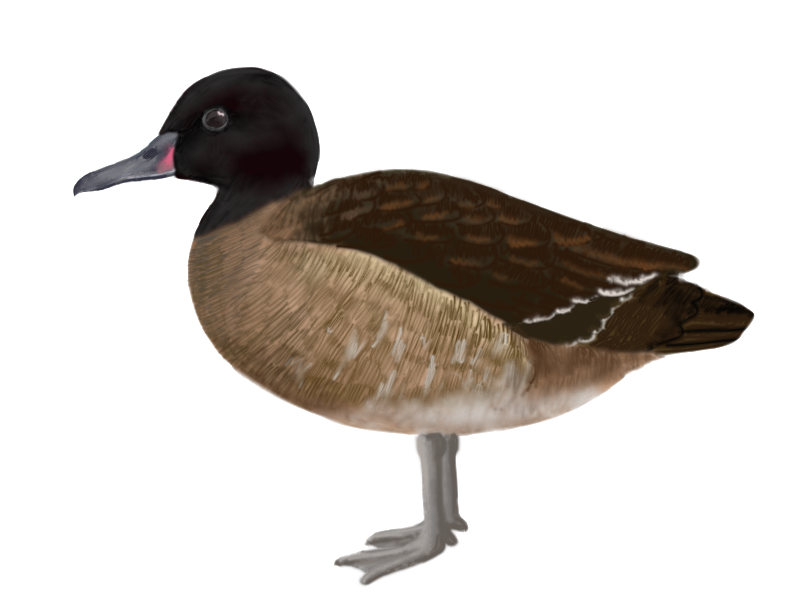

Heteronetta atricapilla

Black-headed Duck

NHMUK:Zoo:S/2002.47.6

GCA_011075105.1

X

X

X

X

X

X

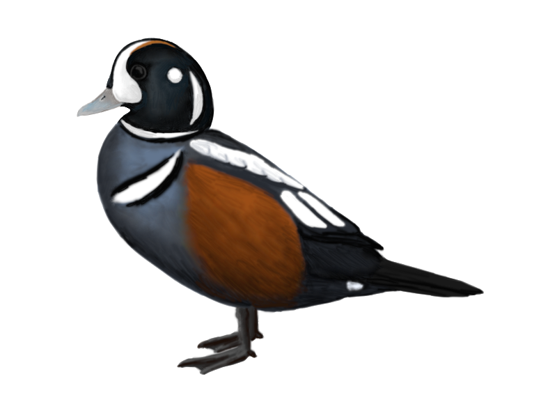

Histrionicus histrionicus

Harlequin Duck

NHMUK:Zoo:1843.6.23.23

X

X

X

X

X

X

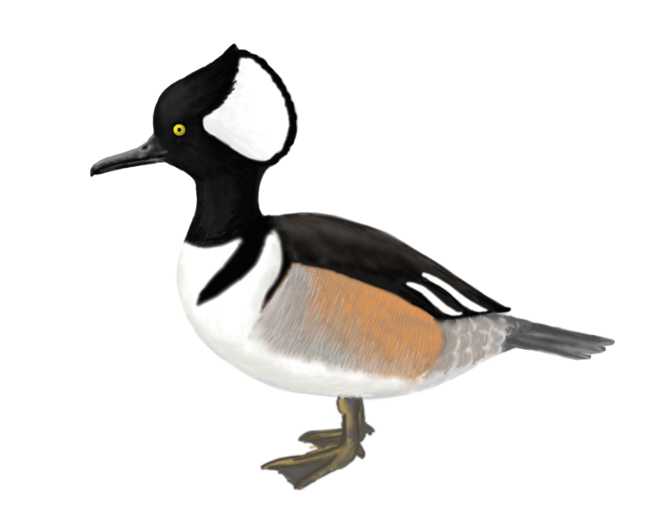

Lophodytes cucullatus

Hooded Merganser

MCZ:Orn:347140

X

X

X

X

X

X

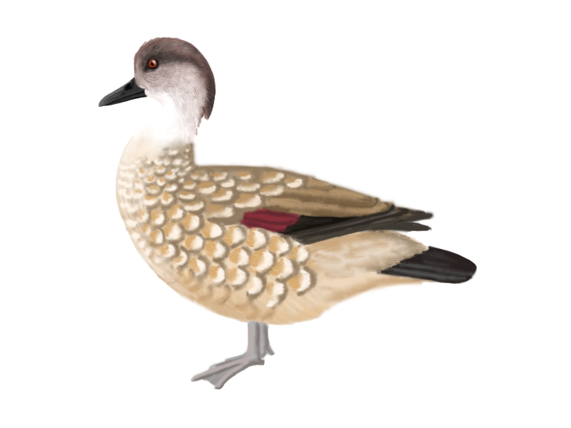

Lophonetta specularioides

Crested Duck

USNM 490992

GCA_032165235.1

X

X

X

X

X

X

X

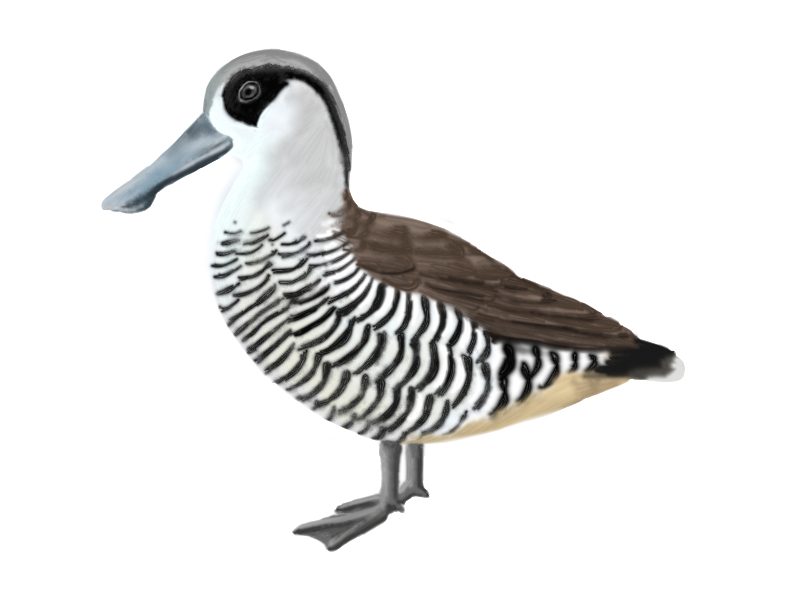

Malacorhynchus membranaceus

Pink-eared Duck

USNM 553596

X

X

X

X

X

X

X

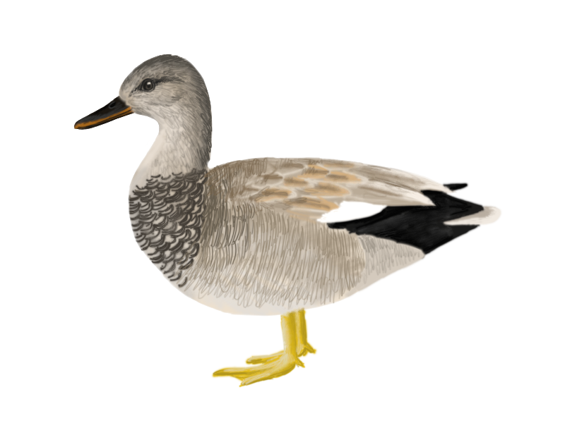

Mareca strepera

Gadwall

MCZ:Orn:341872

GCA_035583915.1

X

X

X

X

X

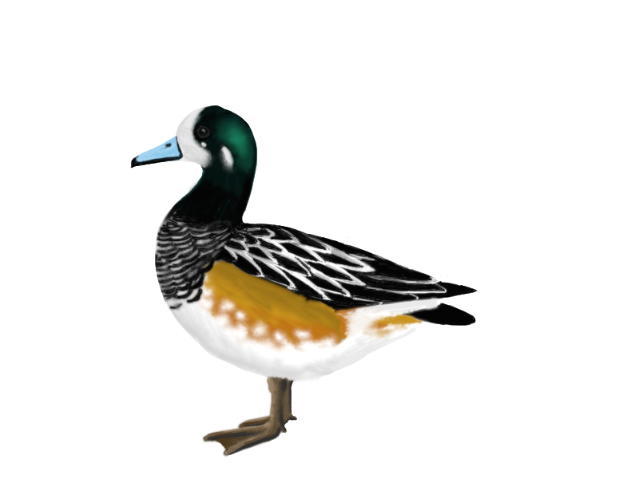

Mareca sibilatrix

Chiloe Wigeon

NHMUK:Zoo:S/1985.72.2

GCA_034783215.1

X

X

X

X

X

X

X

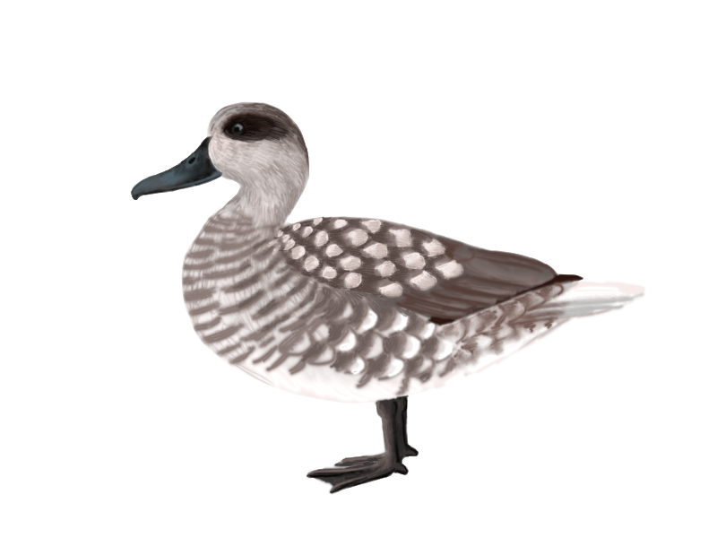

Marmaronetta angustirostris

Marbled Teal

USNM 500299

X

X

X

X

X

X

X

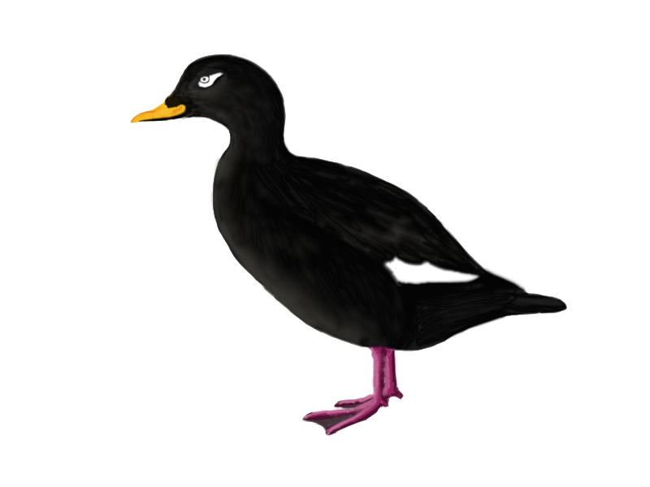

Melanitta fusca

Velvet Scoter

MCZ:Orn:348703

GCA_029620185.1

X

X

X

X

X

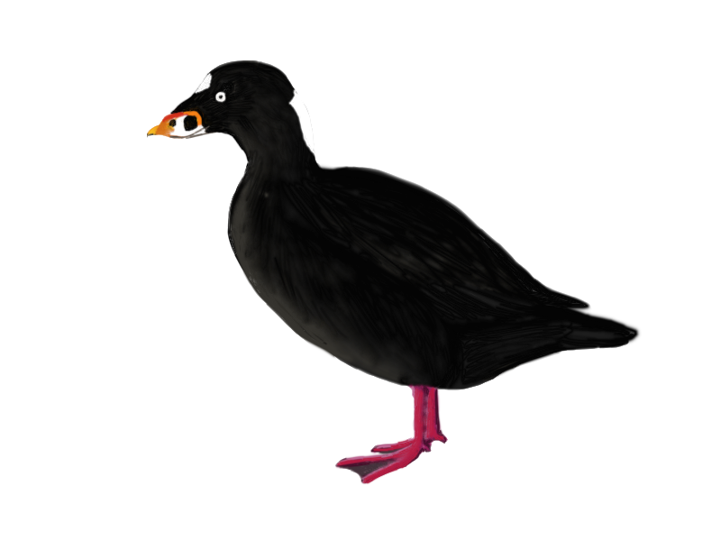

Melanitta perspicillata

Surf Scoter

MCZ:Orn:347151

X

X

X

X

X

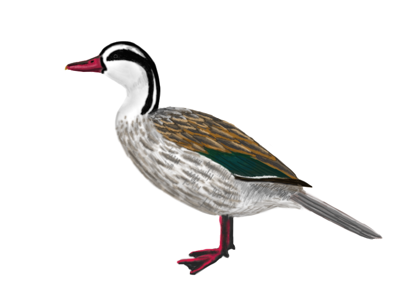

Merganetta armata

Torrent Duck

MCZ:Orn:345094

X

X

X

X

X

X

X

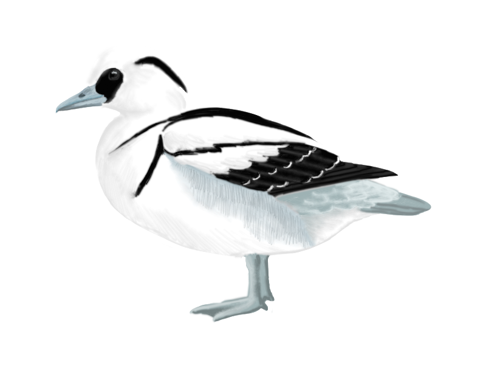

Mergellus albellus

Smew

MCZ:Orn:348520

X

X

X

X

X

X

X

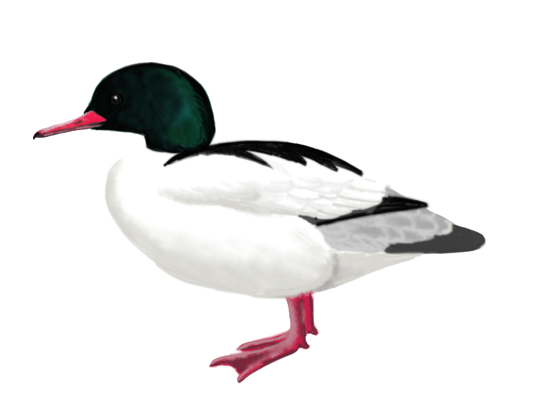

Mergus merganser

Common Merganser

MCZ:Orn:340318

X

X

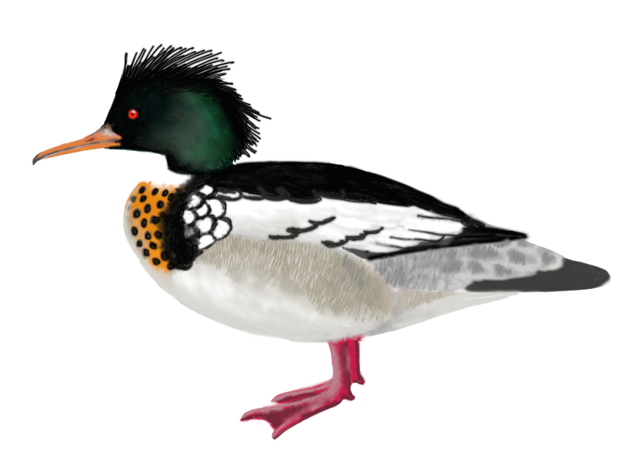

Mergus serrator

Red-breasted Merganser

MCZ:Orn:343636

X

X

X

X

X

X

X

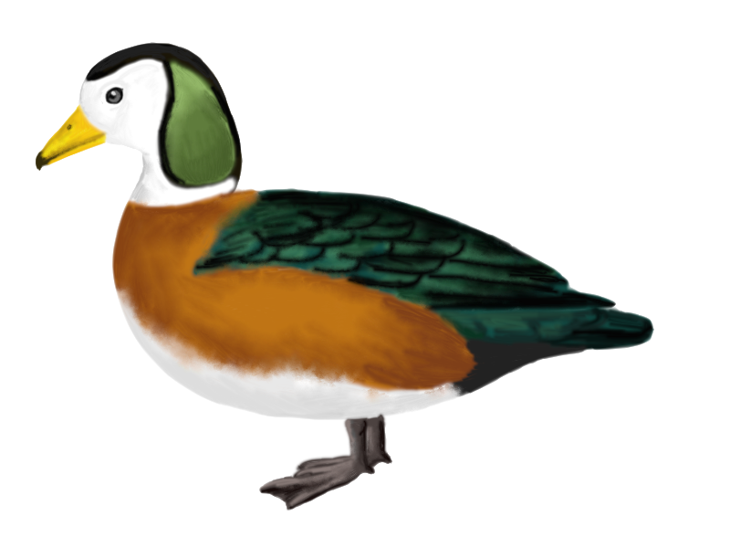

Nettapus auritus

African Pygmy-Goose

MCZ:Orn:341374

GCA_011076525.1

X

X

X

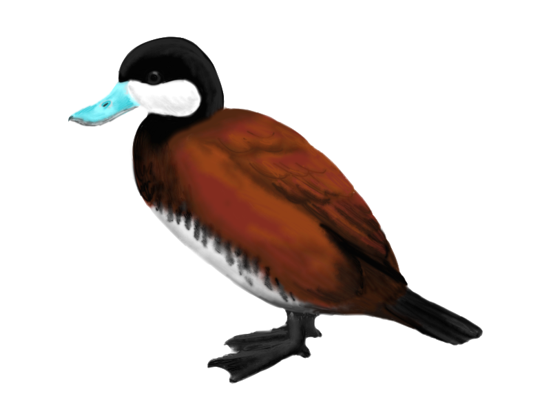

Oxyura jamaicensis

Ruddy Duck

NHMUK:Zoo:S/1985.70.4

GCA_011077185.1

X

X

X

X

X

X

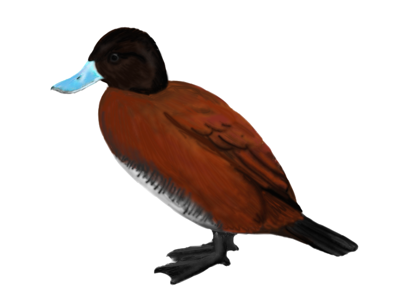

Oxyura ferruginea

Andean Duck

MCZ:Orn:341437

X

X

X

X

X

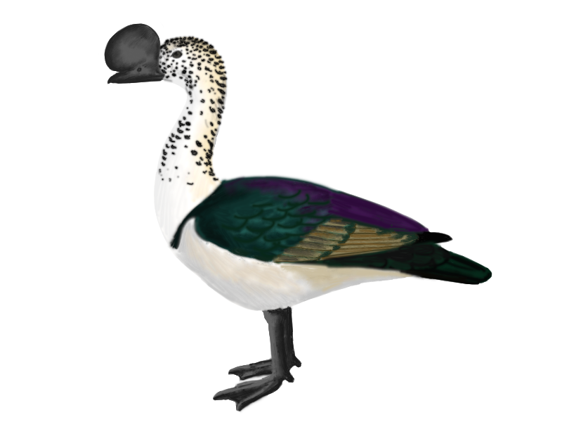

Sarkidiornis melanotos

Knob-billed Duck

USNM 488140

X

X

X

X

X

X

X

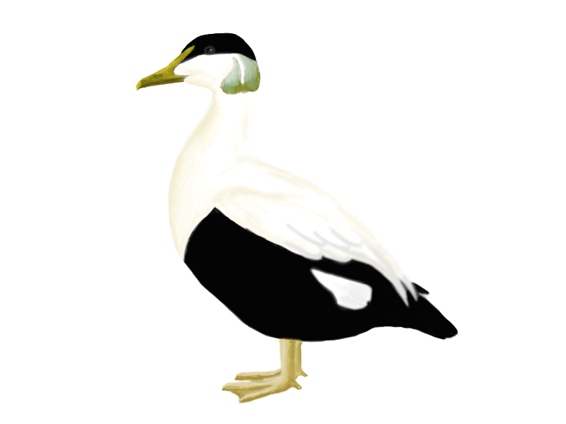

Somateria mollissima

Common Eider

MCZ:Orn:336958

GCA_951411735.1

X

X

X

X

X

X

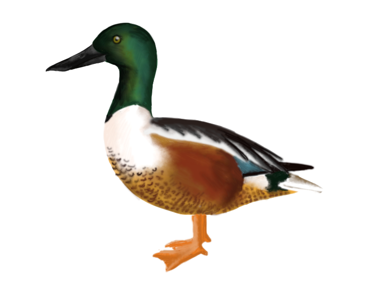

Spatula clypeata

Northern Shoveler

MCZ:Orn:347105

X

X

X

X

X

X

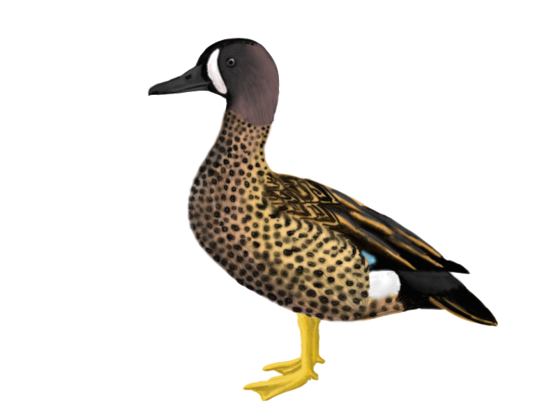

Spatula discors

Blue-winged Teal

NHMUK:Zoo:S/2001.41.5

GCA_032165275.1

X

X

X

X

X

X

X

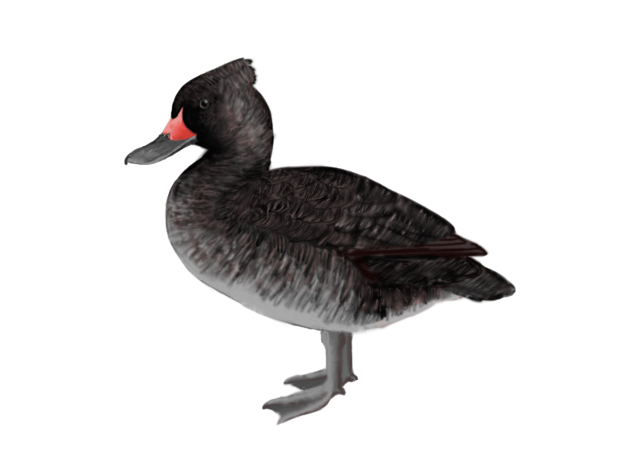

Stictonetta naevosa

Freckled Duck

USNM 555594

GCA_011074415.1

X

X

X

X

X

X

X

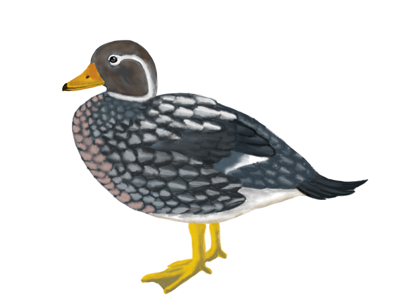

Tachyeres brachypterus

Falkland Steamer-Duck

MCZ:Orn:342206

GCA_032357605.1

X

X

X

X

X

X

X

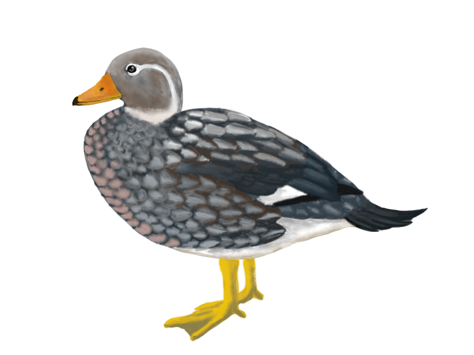

Tachyeres patachonicus

Flying Steamer-Duck

USNM 491013

X

X

X

X

X

X

X

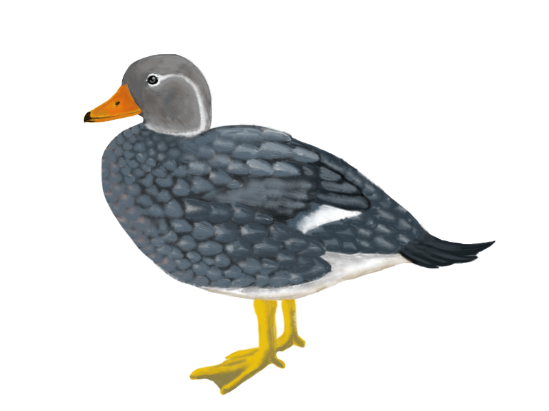

Tachyeres pteneres

Flightless Steamer-Duck

USNM 490930

X

X

X

X

X

X

X

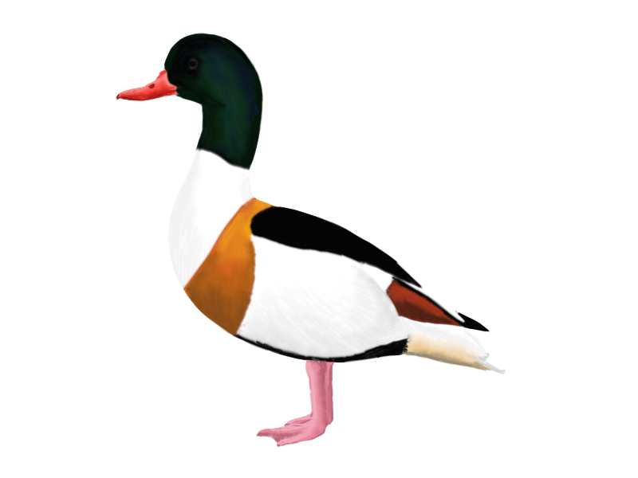

Tadorna tadorna

Common Shelduck

MCZ:Orn:347538

X

X

X

X

X

X

X

# 2 Getting the samples

- **Surface Scanner**: For the surface scanning we used EinScan SE Desktop scanner. After calibration, we put individual bones on the pedestal and ran the algorithm in the program EXScan S v3.1.2.0. Meshes were saved as .obj files.
- **μCT scans**: For the μCT scanning we used the μCT scanner at the Shared Use Facility at the Harvard Museum of Comparative Zoology. Slices were saved as .tif files.
- **Morphosource scans**: For several species, we used material available in the Morphosource public database. We either downloaded the segmented bone mesh or downloaded the raw CT files and used Slicer to segment out the necessary bones.

After all the scans were collected, all scans were roughly aligned at the same coordinate space using the *Align* function in Meshmixer. For CT scans, we removed any internal structure by using the *Select* function to select the outer surface (setting the *Crease Angle Thres* option to >70 that prevents the selection from moving to the internal surface through holes) and using the *Invert* function to switch to internal surface, which were then deleted. We used *Make Solid* function to close any holes on the outside mesh, with a comparable *Solid Accuracy* and *Mesh Density* to avoid over smoothing of scans. Finally we exported this scan as a .obj file.

# 3 Landmarking

## 3.1 Pseudolandmarking

For landmarking, we used the pseudolandmarking (Rolfe, Davis, et al. 2021) approach implemented through PseudoLMGenerator function of SlicerMorph (Rolfe, Pieper, et al. 2021) in Slicer. We used the Mallard Duck (*Anas platyrhynchos*) for the reference specimen to generate the primary landmark for all bones except the tibiotarsus (where the mallard specimen lacks the fibula) where we used the closely related Spot-billed Duck (*Anas zonorhyncha*). Spacing tolerance for each bone was adjusted to apply ~400 pseudolandmarks per bone.

| Bone | Spatial Tolerance | Number of Pseudolandmarks | Point Density Adjustment |
| --- | --- | --- | --- |
| Femur | 2.7 | 459 | 1.7 |
| Tibiotarsus | 2.0 | 480 | 1.9 |
| Tarsometatarsus | 2.8 | 431 | 1.7 |
| Humerus | 2.4 | 458 | 1.9 |
| Radius | 1.8 | 432 | 2.6 |
| Ulna | 2.2 | 452 | 2.0 |
| Carpometacarpus | 2.6 | 432 | 2.6 |

## 3.2 ALPACA

To transfer pseudolanmarks from one species to another, we used the single-template ALPACA framework (Porto et al. 2021). We adjusted the point density adjustment to create meshes of ~4000 points as recommended for ALPACA (values in table above). We used a BCPD acceleration for processing the samples. We used a batch processing to generate landmarks for bones of all the species.

## 3.3 Phylogeny

We used the phylogeny from Chatterji et al. (2026) for this study. For a few taxa missing in the tree that we had scans for, we appended a branch next to the known closest relative species.

```r
duck_data <- xlsx::read.xlsx("Ducks_MCZ.xlsx", sheetIndex = 1, header = T)
duck_data <- duck_data[-66,]

#get body size
duckbm <- log10(duck_data$Body.mass.g)
names(duckbm) <- duck_data$Scientific_Name

#get flight data
flight <- as.factor(duck_data$Flight)
names(flight) <- duck_data$Scientific_Name
flight
```

```
##            Aix_galericulata                  Aix_sponsa
##                           1                           1
##     Amazonetta_brasiliensis                  Anas_acuta
##                           1                           1
##            Anas_aucklandica                 Anas_crecca
##                           0                           1
##         Anas_erythrorhyncha            Anas_laysanensis
##                           1                           1
##          Anas_platyrhynchos               Anas_rubripes
##                           1                           1
##            Anas_zonorhyncha              Anhima_cornuta
##                           1                           1
##             Anser_albifrons          Anser_caerulescens
##                           1                           1
##             Anser_cygnoides            Anser_erythropus
##                           1                           1
##               Anser_fabalis               Anser_indicus
##                           1                           1
##       Anseranas_semipalmata        Asarcornis_scutulata
##                           1                           1
##            Aythya_americana             Aythya_fuligula
##                           1                           1
##             Branta_bernicla           Branta_canadensis
##                           1                           1
##            Branta_leucopsis          Bucephala_clangula
##                           1                           1
##            Cairina_moschata   Cereopsis_novaehollandiae
##                           1                           1
##             Chauna_chavaria           Chenonetta_jubata
##                           1                           1
##          Chloephaga_hybrida            Chloephaga_picta
##                           1                           1
##     Chloephaga_poliocephala       Chloephaga_rubidiceps
##                           1                           1
##           Clangula_hyemalis          Cygnus_columbianus
##                           1                           1
##                 Cygnus_olor      Dendrocygna_autumnalis
##                           1                           1
##         Dendrocygna_bicolor     Heteronetta_atricapilla
##                           1                           1
```

[output cut: 12 more lines]

```
##             Mergus_serrator            Nettapus_auritus
##                           1                           1
##          Oxyura_jamaicensis           Oxyura_ferruginea
##                           1                           1
##      Sarkidiornis_melanotos        Somateria_mollissima
##                           1                           1
##            Spatula_clypeata             Spatula_discors
##                           1                           1
##         Stictonetta_naevosa      Tachyeres_brachypterus
##                           1                           0
##      Tachyeres_patachonicus          Tachyeres_pteneres
##                           1                           0
##             Tadorna_tadorna
##                           1
## Levels: 0 1
```

```r
#get diving data
diving <- as.factor(duck_data$Diving)
names(diving) <- duck_data$Scientific_Name
diving
```

```
##            Aix_galericulata                  Aix_sponsa
##                    Dabbling                    Dabbling
##     Amazonetta_brasiliensis                  Anas_acuta
##                    Dabbling           Occasional_diving
##            Anas_aucklandica                 Anas_crecca
##           Occasional_diving                    Dabbling
##         Anas_erythrorhyncha            Anas_laysanensis
##                    Dabbling                    Dabbling
##          Anas_platyrhynchos               Anas_rubripes
##           Occasional_diving                      Diving
##            Anas_zonorhyncha              Anhima_cornuta
##                    Dabbling                     Walking
##             Anser_albifrons          Anser_caerulescens
##                     Walking                     Walking
##             Anser_cygnoides            Anser_erythropus
##                     Walking             Surface_swimmer
##               Anser_fabalis               Anser_indicus
##             Surface_swimmer             Surface_swimmer
##       Anseranas_semipalmata        Asarcornis_scutulata
##             Surface_swimmer           Occasional_diving
##            Aythya_americana             Aythya_fuligula
##                      Diving                      Diving
##             Branta_bernicla           Branta_canadensis
##                    Dabbling           Occasional_diving
##            Branta_leucopsis          Bucephala_clangula
##             Surface_swimmer                      Diving
##            Cairina_moschata   Cereopsis_novaehollandiae
##             Surface_swimmer                     Walking
##             Chauna_chavaria           Chenonetta_jubata
##                     Walking             Surface_swimmer
##          Chloephaga_hybrida            Chloephaga_picta
##             Surface_swimmer                     Walking
##     Chloephaga_poliocephala       Chloephaga_rubidiceps
##                     Walking                     Walking
##           Clangula_hyemalis          Cygnus_columbianus
##                      Diving                    Dabbling
##                 Cygnus_olor      Dendrocygna_autumnalis
##                    Dabbling                    Dabbling
##         Dendrocygna_bicolor     Heteronetta_atricapilla
##           Occasional_diving                      Diving
```

[output cut: 12 more lines]

```
##             Mergus_serrator            Nettapus_auritus
##                      Diving                    Dabbling
##          Oxyura_jamaicensis           Oxyura_ferruginea
##                      Diving                      Diving
##      Sarkidiornis_melanotos        Somateria_mollissima
##                    Dabbling                      Diving
##            Spatula_clypeata             Spatula_discors
##           Occasional_diving                    Dabbling
##         Stictonetta_naevosa      Tachyeres_brachypterus
##                    Dabbling           Occasional_diving
##      Tachyeres_patachonicus          Tachyeres_pteneres
##                      Diving           Occasional_diving
##             Tadorna_tadorna
##                    Dabbling
## Levels: Dabbling Diving Occasional_diving Surface_swimmer Walking
```

```r
duck_tree <- read.tree("duck_tree.tre")

# Root at the Anhimidae
duck_tree <- root(duck_tree, outgroup = c("Anhima_cornuta", "Chauna_chavaria", "Chauna_torquata"))

# Add missing species
duck_tree <- bind.tip(duck_tree, "Anas_aucklandica", where = which(duck_tree$tip.label=="Anas_chlorotis"), edge.length = 0.0143477498/4, position = 0.0143477498/4)
duck_tree <- bind.tip(duck_tree, "Anas_zonorhyncha", where = which(duck_tree$tip.label=="Anas_platyrhynchos"), edge.length = 0.0022507147/4, position = 0.0022507147/4)
duck_tree <- bind.tip(duck_tree, "Anser_erythropus", where = which(duck_tree$tip.label=="Anser_albifrons"), edge.length = 0.0017958047/4, position = 0.0017958047/4)
duck_tree <- bind.tip(duck_tree, "Asarcornis_scutulata", where = which(duck_tree$tip.label=="Cairina_moschata"), edge.length = 0.0067085060/4, position = 0.0067085060/4)
duck_tree$tip.label[which(duck_tree$tip.label == "Malacorhyncus_membranaceus")] <- "Malacorhynchus_membranaceus"
duck_tree <- bind.tip(duck_tree, "Mergus_merganser", where = which(duck_tree$tip.label=="Mergus_serrator"), edge.length = 0.0027206995/4, position = 0.0027206995/4)
duck_tree <- bind.tip(duck_tree, "Oxyura_ferruginea", where = which(duck_tree$tip.label=="Oxyura_jamaicensis"), edge.length = 0.0024525321/4, position = 0.0024525321/4)
duck_tree <- bind.tip(duck_tree, "Spatula_discors", where = which(duck_tree$tip.label=="Spatula_cyanoptera"), edge.length = 0.0027173372/4, position = 0.0027173372/4)
duck_tree <- bind.tip(duck_tree, "Anas_crecca", where = which(duck_tree$tip.label=="Anas_flavirostris"), edge.length = 0.0032631134/4, position = 0.0032631134/4)

duck_tree_orig <- duck_tree
```

## 3.4 GPA and PCA

To conduct a Generalized Procrustes Analysis we used the **gpagen** function of the geommorph package. We first summarized the information for all the specimens of a single bone using the *GPA* function in SlicerMorph to allow for easier upload into R work environment. For pca we used **gm.prcomp** with phylogeny from above.

### 3.4.1 Femur

[figure not shown]

```r
# Load summarized data for all landmark files
logfile <- parser("gpa/Femur/analysis.log", forceLPS = T)

# Run GPA
femur.gpa <- gpagen(logfile$LM, print.progress = F)
femurshape <- femur.gpa$coords
dimnames(femurshape)[[3]] <- sub("^([^_]+_[^_]+).*", "\\1", dimnames(femurshape)[[3]])
femursize <- log10(femur.gpa$Csize)
names(femursize) <- dimnames(femurshape)[[3]]

# Subset phylogenetic tree to keep only taxa for which scans exist
duck_tree_femur <- keep.tip(duck_tree_orig, duck_data$Scientific_Name[duck_data$Femur %in% "X"])

dimnames(femur.gpa$coords)[[3]] <- unlist(lapply(str_split(dimnames(femur.gpa$coords)[[3]], "_"), FUN = function(x){paste(x[1], x[2], sep="_")}))
femur_pca <- gm.prcomp(femur.gpa$coords, phy = duck_tree_femur)

# pc1 (25.87%), pc2 (19.36%), pc3 (7.10%), pc4 (5.34%), pc5 (5.01%)

asp_ratio <- 1.618
duck_pca <- data.frame(species=names(femur_pca$x[,1]), PC1=femur_pca$x[,1], PC2=femur_pca$x[,2], PC3=femur_pca$x[,3])
duck_pca <- merge(duck_pca, duck_data[,c("Scientific_Name", "Images", "Femur")], by.x = "species", by.y = "Scientific_Name", all.x = T, all.y = F)
g1 <- ggplot(duck_pca, aes(PC1, PC2)) +
      geom_image(aes(image=Images), size=0.075, by = "width", asp = asp_ratio)+
      theme_classic()+
      theme(aspect.ratio = 1/asp_ratio)

g1
```

Then we check for convergence

```r
femurshape <- femurshape[,,duck_tree_femur$tip.label]
femursize <- femursize[duck_tree_femur$tip.label]
femurbm <- duckbm[duck_tree_femur$tip.label]
femflight <- flight[duck_tree_femur$tip.label]
femdiving <- diving[duck_tree_femur$tip.label]

femallom1 <- procD.pgls(femurshape ~ femurbm, phy = duck_tree_femur, SS.type = "II", iter = 999)
summary(femallom1)
femallom2 <- procD.pgls(femurshape ~ femursize, phy = duck_tree_femur,SS.type = "II", iter = 999)
summary(femallom2)
femallom3 <- procD.pgls(femurshape ~ femurbm + femursize, phy = duck_tree_femur, SS.type = "II", iter = 999)
summary(femallom3)
femur.mod <- procD.pgls(femurshape ~ femurbm + femursize + femdiving, phy = duck_tree_femur, SS.type = "II", iter = 999)
summary(femur.mod)
femur.mod <- procD.pgls(femurshape ~ femurbm + femursize + femdiving + femflight, phy = duck_tree_femur, SS.type = "II", iter = 999)
summary(femur.mod)

#convergence

### find convergence test for 3D data
femdivelist <- names(femdiving[femdiving  == "Diving"])
femdivconv <- convrat(duck_tree_femur, femur_pca$x[,1:5], femdivelist)

femdivconvsig <- convratsig(duck_tree_femur, femur_pca$x[,1:5], femdivelist, 10)
femdivconvsig

## convergence in flightless ducks
femflightlesslist <- names(femflight[femflight == "0"])
femflightlessconv <- convrat(femurtree, femur_pca$x[,1:5], femflightlesslist)
femflightlessconv

femflightconvsig <- convratsig(femurtree, femur_pca$x[,1:5], femflightlesslist, 10)
femflightconvsig

## Convergence test with PC axes
femconv <- conv.map(femdivelist, scores = femur_pca$x, pcs = femur_pca$rotation, mshape = femurmean, focal = "Somateria_mollissima" )
femconvtest <- convnum(duck_tree_femur, femur_pca$x[,1:5], femdivelist)
```

We also generated warped meshes to visualize bone structure relevant to the different PC axes.

```r
ref <- mshape(femur.gpa$coords)
ref_obj <- read.ply("Anas_platyrhynchos_MCZ347156_femur.ply", ShowSpecimen = F)
ref_lnd <- readland.fcsv("Anas_platyrhynchos_MCZ347156_femur_new.fcsv")
warped_ref <- warpRefMesh(ref_obj, ref_lnd, ref, color = "ivory", centered = FALSE)

g2 <- plotRefToTarget(ref, pca$shapes$shapes.comp1$min, mesh=warped_ref, method = "surface")
g3 <- plotRefToTarget(ref, pca$shapes$shapes.comp1$max, mesh=warped_ref, method = "surface")
g4 <- plotRefToTarget(ref, pca$shapes$shapes.comp2$min, mesh=warped_ref, method = "surface")
g5 <- plotRefToTarget(ref, pca$shapes$shapes.comp2$max, mesh=warped_ref, method = "surface")

mesh2ply(warped_ref, "femur_ref")
mesh2ply(g2, "femur_pc1_min")
mesh2ply(g3, "femur_pc1_max")
mesh2ply(g4, "femur_pc2_min")
mesh2ply(g5, "femur_pc2_max")
```

### 3.4.2 Tibiotarsus

[figure not shown]

```r
logfile <- parser("gpa/Tibiotarsus/analysis.log", forceLPS = T)
tibiotarsus.gpa <- gpagen(logfile$LM, print.progress = F)

tibioshape <- tibiotarsus.gpa$coords
dimnames(tibioshape)[[3]] <- sub("^([^_]+_[^_]+).*", "\\1", dimnames(tibioshape)[[3]])
tibiosize <- log10(tibiotarsus.gpa$Csize)
names(tibiosize) <- dimnames(tibioshape)[[3]]

duck_tree_tibio <- keep.tip(duck_tree_orig, duck_data$Scientific_Name[duck_data$Tibiotarsus %in% "X"])

dimnames(tibiotarsus.gpa$coords)[[3]] <- unlist(lapply(str_split(dimnames(tibiotarsus.gpa$coords)[[3]], "_"), FUN = function(x){paste(x[1], x[2], sep="_")}))
tibio_pca <- gm.prcomp(tibiotarsus.gpa$coords, phy = duck_tree_tibio)

# pc1 (29.38%), pc2 (11.31%), pc3 (10.16%), pc4 (7.18%), pc5 (4.51%)

asp_ratio <- 1.618
duck_pca <- data.frame(species=names(tibio_pca$x[,1]), PC1=tibio_pca$x[,1], PC2=tibio_pca$x[,2], PC3=tibio_pca$x[,3], PC4=tibio_pca$x[,4], PC5=tibio_pca$x[,5])
duck_pca <- merge(duck_pca, duck_data[,c("Scientific_Name", "Images", "Tibiotarsus")], by.x = "species", by.y = "Scientific_Name", all.x = T, all.y = F)
g1 <- ggplot(duck_pca, aes(PC1, PC3)) +
  geom_image(aes(image=Images), size=0.075, by = "width", asp = asp_ratio)+
  theme_classic()+
  theme(aspect.ratio = 1/asp_ratio)

g1
```

Then we check for convergence

```r
tibioshape <- tibioshape[,,duck_tree_tibio$tip.label]
tibiosize <- tibiosize[duck_tree_tibio$tip.label]
tibiobm <- duckbm[duck_tree_tibio$tip.label]
tibioflight <- flight[duck_tree_tibio$tip.label]
tibiodiving <- diving[duck_tree_tibio$tip.label]

tibioallom1 <- procD.pgls(tibioshape ~ tibiobm, phy = duck_tree_tibio, SS.type = "II", iter = 999)
summary(tibioallom1)
tibioallom2 <- procD.pgls(tibioshape ~ tibiosize, phy = duck_tree_tibio,SS.type = "II", iter = 999)
summary(tibioallom2)
tibioallom3 <- procD.pgls(tibioshape ~ tibiobm + tibiosize, phy = duck_tree_tibio, SS.type = "II", iter = 999)
summary(tibioallom3)
tibio.mod <- procD.pgls(tibioshape ~ tibiobm + tibiosize + tibiodiving, phy = duck_tree_tibio, SS.type = "II", iter = 999)
summary(tibio.mod)
tibio.mod <- procD.pgls(tibioshape ~ tibiobm + tibiosize + tibiodiving + tibioflight, phy = duck_tree_tibio, SS.type = "II", iter = 999)
summary(tibio.mod)

#convergence

### find convergence test for 3D data
tibiodivelist <- names(tibiodiving[tibiodiving  == "Diving"])
tibiodivconv <- convrat(duck_tree_tibio, tibio_pca$x[,1:5], tibiodivelist)

tibiodivconvsig <- convratsig(duck_tree_tibio, tibio_pca$x[,1:5], tibiodivelist, 10)
tibiodivconvsig

## convergence in flightless ducks
tibioflightlesslist <- names(tibioflight[tibioflight == "0"])
tibioflightlessconv <- convrat(tibiotree, tibio_pca$x[,1:5], tibioflightlesslist)
tibioflightlessconv

tibioflightconvsig <- convratsig(tibiotree, tibio_pca$x[,1:5], tibioflightlesslist, 10)
tibioflightconvsig

## Convergence test with PC axes
tibioconv <- conv.map(tibiodivelist, scores = tibio_pca$x, pcs = tibio_pca$rotation, mshape = tibiomean, focal = "Somateria_mollissima" )
tibioconvtest <- convnum(duck_tree_tibio, tibio_pca$x[,1:5], tibiodivelist)
```

```r
ref <- mshape(tibiotarsus.gpa$coords)
ref_obj <- read.ply("Anas_zonorhyncha_USNM633481_tibiotarsus.ply", ShowSpecimen = F)
ref_lnd <- readland.fcsv("Anas_zonorhyncha_USNM633481_tibiotarsus.fcsv")
warped_ref <- warpRefMesh(ref_obj, ref_lnd, ref, color = "ivory", centered = FALSE)

g2 <- plotRefToTarget(ref, pca$shapes$shapes.comp1$min, mesh=warped_ref, method = "surface")
g3 <- plotRefToTarget(ref, pca$shapes$shapes.comp1$max, mesh=warped_ref, method = "surface")
g4 <- plotRefToTarget(ref, pca$shapes$shapes.comp3$min, mesh=warped_ref, method = "surface")
g5 <- plotRefToTarget(ref, pca$shapes$shapes.comp3$max, mesh=warped_ref, method = "surface")

mesh2ply(warped_ref, "tibiotarsus_ref")
mesh2ply(g2, "tibiotarsus_pc1_min")
mesh2ply(g3, "tibiotarsus_pc1_max")
mesh2ply(g4, "tibiotarsus_pc3_min")
mesh2ply(g5, "tibiotarsus_pc3_max")
```

### 3.4.3 Tarsometatarsus

[figure not shown]

```r
logfile <- parser("gpa/Tarsometatarsus/analysis.log", forceLPS = T)
tarsometatarsus.gpa <- gpagen(logfile$LM, print.progress = F)

tarsoshape <- tarsometatarsus.gpa$coords
dimnames(tarsoshape)[[3]] <- sub("^([^_]+_[^_]+).*", "\\1", dimnames(tarsoshape)[[3]])
tarsosize <- log10(tarsometatarsus.gpa$Csize)
names(tarsosize) <- dimnames(tarsoshape)[[3]]

duck_tree_tarso <- keep.tip(duck_tree_orig, duck_data$Scientific_Name[duck_data$Tarsometatarsus %in% "X"])

dimnames(tarsometatarsus.gpa$coords)[[3]] <- unlist(lapply(str_split(dimnames(tarsometatarsus.gpa$coords)[[3]], "_"), FUN = function(x){paste(x[1], x[2], sep="_")}))
tarso_pca <- gm.prcomp(tarsometatarsus.gpa$coords, phy = duck_tree_tarso)

# pc1 (40.49%), pc2 (10.91%), pc3 (7.74%), pc4 (5.44%), pc5 (4.45%)

asp_ratio <- 1.618
duck_pca <- data.frame(species=names(tarso_pca$x[,1]), PC1=tarso_pca$x[,1], PC2=tarso_pca$x[,2], PC3=tarso_pca$x[,3], PC4=tarso_pca$x[,4], PC5=tarso_pca$x[,5])
duck_pca <- merge(duck_pca, duck_data[,c("Scientific_Name", "Images", "Tarsometatarsus")], by.x = "species", by.y = "Scientific_Name", all.x = T, all.y = F)
g1 <- ggplot(duck_pca, aes(PC1, PC2)) +
  geom_image(aes(image=Images), size=0.075, by = "width", asp = asp_ratio)+
  theme_classic()+
  theme(aspect.ratio = 1/asp_ratio)

g1
```

Then we check for convergence

```r
tarsoshape <- tarsoshape[,,duck_tree_tarso$tip.label]
tarsosize <- tarsosize[duck_tree_tarso$tip.label]
tarsobm <- duckbm[duck_tree_tarso$tip.label]
tarsoflight <- flight[duck_tree_tarso$tip.label]
tarsodiving <- diving[duck_tree_tarso$tip.label]

tarsoallom1 <- procD.pgls(tarsoshape ~ tarsobm, phy = duck_tree_tarso, SS.type = "II", iter = 999)
summary(tarsoallom1)
tarsoallom2 <- procD.pgls(tarsoshape ~ tarsosize, phy = duck_tree_tarso,SS.type = "II", iter = 999)
summary(tarsoallom2)
tarsoallom3 <- procD.pgls(tarsoshape ~ tarsobm + tarsosize, phy = duck_tree_tarso, SS.type = "II", iter = 999)
summary(tarsoallom3)
tarso.mod <- procD.pgls(tarsoshape ~ tarsobm + tarsosize + tarsodiving, phy = duck_tree_tarso, SS.type = "II", iter = 999)
summary(tarso.mod)
tarso.mod <- procD.pgls(tarsoshape ~ tarsobm + tarsosize + tarsodiving + tarsoflight, phy = duck_tree_tarso, SS.type = "II", iter = 999)
summary(tarso.mod)

#convergence

### find convergence test for 3D data
tarsodivelist <- names(tarsodiving[tarsodiving  == "Diving"])
tarsodivconv <- convrat(duck_tree_tarso, tarso_pca$x[,1:5], tarsodivelist)

tarsodivconvsig <- convratsig(duck_tree_tarso, tarso_pca$x[,1:5], tarsodivelist, 10)
tarsodivconvsig

## convergence in flightless ducks
tarsoflightlesslist <- names(tarsoflight[tarsoflight == "0"])
tarsoflightlessconv <- convrat(tarsotree, tarso_pca$x[,1:5], tarsoflightlesslist)
tarsoflightlessconv

tarsoflightconvsig <- convratsig(tarsotree, tarso_pca$x[,1:5], tarsoflightlesslist, 10)
tarsoflightconvsig

## Convergence test with PC axes
tarsoconv <- conv.map(tarsodivelist, scores = tarso_pca$x, pcs = tarso_pca$rotation, mshape = tarsomean, focal = "Somateria_mollissima" )
tarsoconvtest <- convnum(duck_tree_tarso, tarso_pca$x[,1:5], tarsodivelist)
```

```r
ref <- mshape(tarsometatarsus.gpa$coords)
ref_obj <- read.ply("Anas_platyrhynchos_MCZ347156_tarsometatarsus.ply", ShowSpecimen = F)
ref_lnd <- readland.fcsv("Anas_platyrhynchos_MCZ347156_tarsometatarsus.fcsv")
warped_ref <- warpRefMesh(ref_obj, ref_lnd, ref, color = "ivory", centered = FALSE)

g2 <- plotRefToTarget(ref, pca$shapes$shapes.comp1$min, mesh=warped_ref, method = "surface")
g3 <- plotRefToTarget(ref, pca$shapes$shapes.comp1$max, mesh=warped_ref, method = "surface")
g4 <- plotRefToTarget(ref, pca$shapes$shapes.comp2$min, mesh=warped_ref, method = "surface")
g5 <- plotRefToTarget(ref, pca$shapes$shapes.comp2$max, mesh=warped_ref, method = "surface")

mesh2ply(warped_ref, "tarsometatarsus_ref")
mesh2ply(g2, "tarsometatarsus_pc1_min")
mesh2ply(g3, "tarsometatarsus_pc1_max")
mesh2ply(g4, "tarsometatarsus_pc2_min")
mesh2ply(g5, "tarsometatarsus_pc2_max")
```

### 3.4.4 Humerus

[figure not shown]

```r
logfile <- parser("gpa/Humerus/analysis.log", forceLPS = T)
humerus.gpa <- gpagen(logfile$LM, print.progress = F)

humershape <- humerus.gpa$coords
dimnames(humershape)[[3]] <- sub("^([^_]+_[^_]+).*", "\\1", dimnames(humershape)[[3]])
humersize <- log10(humerus.gpa$Csize)
names(humersize) <- dimnames(humershape)[[3]]

duck_tree_humer <- keep.tip(duck_tree_orig, duck_data$Scientific_Name[duck_data$Humerus %in% "X"])
duck_tree_humer <- root(duck_tree_humer, outgroup = c("Anhima_cornuta", "Chauna_chavaria"))

dimnames(humerus.gpa$coords)[[3]] <- unlist(lapply(str_split(dimnames(humerus.gpa$coords)[[3]], "_"), FUN = function(x){paste(x[1], x[2], sep="_")}))
humer_pca <- gm.prcomp(humerus.gpa$coords, phy = duck_tree_humer)

# pc1 (24.13%), pc2 (12.16%), pc3 (9.49%), pc4 (8.66%), pc5 (6.59%)

asp_ratio <- 1.618
duck_pca <- data.frame(species=names(humer_pca$x[,1]), PC1=humer_pca$x[,1], PC2=humer_pca$x[,2], PC3=humer_pca$x[,3])
duck_pca <- merge(duck_pca, duck_data[,c("Scientific_Name", "Images", "Humerus")], by.x = "species", by.y = "Scientific_Name", all.x = T, all.y = F)
g1 <- ggplot(duck_pca, aes(PC1, PC2)) +
  geom_image(aes(image=Images), size=0.075, by = "width", asp = asp_ratio)+
  theme_classic()+
  theme(aspect.ratio = 1/asp_ratio)

g1
```

Then we check for convergence

```r
humershape <- humershape[,,duck_tree_humer$tip.label]
humersize <- humersize[duck_tree_humer$tip.label]
humerbm <- duckbm[duck_tree_humer$tip.label]
humerflight <- flight[duck_tree_humer$tip.label]
humerdiving <- diving[duck_tree_humer$tip.label]

humerallom1 <- procD.pgls(humershape ~ humerbm, phy = duck_tree_humer, SS.type = "II", iter = 999)
summary(humerallom1)
humerallom2 <- procD.pgls(humershape ~ humersize, phy = duck_tree_humer,SS.type = "II", iter = 999)
summary(humerallom2)
humerallom3 <- procD.pgls(humershape ~ humerbm + humersize, phy = duck_tree_humer, SS.type = "II", iter = 999)
summary(humerallom3)
humer.mod <- procD.pgls(humershape ~ humerbm + humersize + humerdiving, phy = duck_tree_humer, SS.type = "II", iter = 999)
summary(humer.mod)
humer.mod <- procD.pgls(humershape ~ humerbm + humersize + humerdiving + humerflight, phy = duck_tree_humer, SS.type = "II", iter = 999)
summary(humer.mod)

#convergence

### find convergence test for 3D data
humerdivelist <- names(humerdiving[humerdiving  == "Diving"])
humerdivconv <- convrat(duck_tree_humer, humer_pca$x[,1:5], humerdivelist)

humerdivconvsig <- convratsig(duck_tree_humer, humer_pca$x[,1:5], humerdivelist, 10)
humerdivconvsig

## convergence in flightless ducks
humerflightlesslist <- names(humerflight[humerflight == "0"])
humerflightlessconv <- convrat(humertree, humer_pca$x[,1:5], humerflightlesslist)
humerflightlessconv

humerflightconvsig <- convratsig(humertree, humer_pca$x[,1:5], humerflightlesslist, 10)
humerflightconvsig

## Convergence test with PC axes
humerconv <- conv.map(humerdivelist, scores = humer_pca$x, pcs = humer_pca$rotation, mshape = humermean, focal = "Somateria_mollissima" )
humerconvtest <- convnum(duck_tree_humer, humer_pca$x[,1:5], humerdivelist)
```

```r
ref <- mshape(humerus.gpa$coords)
ref_obj <- read.ply("Anas_platyrhynchos_MCZ347156_humerus.ply", ShowSpecimen = F)
ref_lnd <- readland.fcsv("Anas_platyrhynchos_MCZ347156_humerus_new.fcsv")
warped_ref <- warpRefMesh(ref_obj, ref_lnd, ref, color = "ivory", centered = FALSE)

g2 <- plotRefToTarget(ref, pca$shapes$shapes.comp1$min, mesh=warped_ref, method = "surface")
g3 <- plotRefToTarget(ref, pca$shapes$shapes.comp1$max, mesh=warped_ref, method = "surface")
g4 <- plotRefToTarget(ref, pca$shapes$shapes.comp2$min, mesh=warped_ref, method = "surface")
g5 <- plotRefToTarget(ref, pca$shapes$shapes.comp2$max, mesh=warped_ref, method = "surface")

mesh2ply(warped_ref, "humerus_ref")
mesh2ply(g2, "humerus_pc1_min")
mesh2ply(g3, "humerus_pc1_max")
mesh2ply(g4, "humerus_pc2_min")
mesh2ply(g5, "humerus_pc2_max")
```

### 3.4.5 Radius

[figure not shown]

```r
logfile <- parser("gpa/Radius/analysis.log", forceLPS = T)
radius.gpa <- gpagen(logfile$LM, print.progress = F)

radiishape <- radius.gpa$coords
dimnames(radiishape)[[3]] <- sub("^([^_]+_[^_]+).*", "\\1", dimnames(radiishape)[[3]])
radiisize <- log10(radius.gpa$Csize)
names(radiisize) <- dimnames(radiishape)[[3]]

duck_tree_radii <- keep.tip(duck_tree_orig, duck_data$Scientific_Name[duck_data$Radius %in% "X"])

dimnames(radius.gpa$coords)[[3]] <- unlist(lapply(str_split(dimnames(radius.gpa$coords)[[3]], "_"), FUN = function(x){paste(x[1], x[2], sep="_")}))
radii_pca <- gm.prcomp(radius.gpa$coords, phy = duck_tree_radii)

# pc1 (28.75%), pc2 (18.06%), pc3 (10.83%), pc4 (9.17%), pc5 (5.86%)

asp_ratio <- 1.618
duck_pca <- data.frame(species=names(radii_pca$x[,1]), PC1=radii_pca$x[,1], PC2=radii_pca$x[,2], PC3=radii_pca$x[,3], PC4=radii_pca$x[,4], PC5=radii_pca$x[,5])
duck_pca <- merge(duck_pca, duck_data[,c("Scientific_Name", "Images", "Radius")], by.x = "species", by.y = "Scientific_Name", all.x = T, all.y = F)
g1 <- ggplot(duck_pca, aes(PC1, PC2)) +
  geom_image(aes(image=Images), size=0.075, by = "width", asp = asp_ratio)+
  theme_classic()+
  theme(aspect.ratio = 1/asp_ratio)

g1
```

Then we check for convergence

```r
radiishape <- radiishape[,,duck_tree_radii$tip.label]
radiisize <- radiisize[duck_tree_radii$tip.label]
radiibm <- duckbm[duck_tree_radii$tip.label]
radiiflight <- flight[duck_tree_radii$tip.label]
radiidiving <- diving[duck_tree_radii$tip.label]

radiiallom1 <- procD.pgls(radiishape ~ radiibm, phy = duck_tree_radii, SS.type = "II", iter = 999)
summary(radiiallom1)
radiiallom2 <- procD.pgls(radiishape ~ radiisize, phy = duck_tree_radii,SS.type = "II", iter = 999)
summary(radiiallom2)
radiiallom3 <- procD.pgls(radiishape ~ radiibm + radiisize, phy = duck_tree_radii, SS.type = "II", iter = 999)
summary(radiiallom3)
radii.mod <- procD.pgls(radiishape ~ radiibm + radiisize + radiidiving, phy = duck_tree_radii, SS.type = "II", iter = 999)
summary(radii.mod)
radii.mod <- procD.pgls(radiishape ~ radiibm + radiisize + radiidiving + radiiflight, phy = duck_tree_radii, SS.type = "II", iter = 999)
summary(radii.mod)

#convergence

### find convergence test for 3D data
radiidivelist <- names(radiidiving[radiidiving  == "Diving"])
radiidivconv <- convrat(duck_tree_radii, radii_pca$x[,1:5], radiidivelist)

radiidivconvsig <- convratsig(duck_tree_radii, radii_pca$x[,1:5], radiidivelist, 10)
radiidivconvsig

## convergence in flightless ducks
radiiflightlesslist <- names(radiiflight[radiiflight == "0"])
radiiflightlessconv <- convrat(radiitree, radii_pca$x[,1:5], radiiflightlesslist)
radiiflightlessconv

radiiflightconvsig <- convratsig(radiitree, radii_pca$x[,1:5], radiiflightlesslist, 10)
radiiflightconvsig

## Convergence test with PC axes
radiiconv <- conv.map(radiidivelist, scores = radii_pca$x, pcs = radii_pca$rotation, mshape = radiimean, focal = "Somateria_mollissima" )
radiiconvtest <- convnum(duck_tree_radii, radii_pca$x[,1:5], radiidivelist)
```

```r
ref <- mshape(radius.gpa$coords)
ref_obj <- read.ply("Anas_platyrhynchos_MCZ347156_radius.ply", ShowSpecimen = F)
ref_lnd <- readland.fcsv("Anas_platyrhynchos_MCZ347156_radius.fcsv")
warped_ref <- warpRefMesh(ref_obj, ref_lnd, ref, color = "ivory", centered = FALSE)

g2 <- plotRefToTarget(ref, pca$shapes$shapes.comp1$min, mesh=warped_ref, method = "surface")
g3 <- plotRefToTarget(ref, pca$shapes$shapes.comp1$max, mesh=warped_ref, method = "surface")
g4 <- plotRefToTarget(ref, pca$shapes$shapes.comp2$min, mesh=warped_ref, method = "surface")
g5 <- plotRefToTarget(ref, pca$shapes$shapes.comp2$max, mesh=warped_ref, method = "surface")

mesh2ply(warped_ref, "radius_ref")
mesh2ply(g2, "radius_pc1_min")
mesh2ply(g3, "radius_pc1_max")
mesh2ply(g4, "radius_pc2_min")
mesh2ply(g5, "radius_pc2_max")
```

### 3.4.6 Ulna

[figure not shown]

```r
logfile <- parser("gpa/Ulna/analysis.log", forceLPS = T)
ulna.gpa <- gpagen(logfile$LM, print.progress = F)

ulnashape <- ulna.gpa$coords
dimnames(ulnashape)[[3]] <- sub("^([^_]+_[^_]+).*", "\\1", dimnames(ulnashape)[[3]])
ulnasize <- log10(ulna.gpa$Csize)
names(ulnasize) <- dimnames(ulnashape)[[3]]

duck_tree_ulna <- keep.tip(duck_tree_orig, duck_data$Scientific_Name[duck_data$Ulna %in% "X"])

dimnames(ulna.gpa$coords)[[3]] <- unlist(lapply(str_split(dimnames(ulna.gpa$coords)[[3]], "_"), FUN = function(x){paste(x[1], x[2], sep="_")}))
ulna_pca <- gm.prcomp(ulna.gpa$coords, phy = duck_tree_ulna)

# pc1 (28.35%), pc2 (19.04%), pc3 (14.70%), pc4 (7.03%), pc5 (5.61%)

asp_ratio <- 1.618
duck_pca <- data.frame(species=names(ulna_pca$x[,1]), PC1=ulna_pca$x[,1], PC2=ulna_pca$x[,2], PC3=ulna_pca$x[,3], PC4=ulna_pca$x[,4], PC5=ulna_pca$x[,5])
duck_pca <- merge(duck_pca, duck_data[,c("Scientific_Name", "Images", "Ulna")], by.x = "species", by.y = "Scientific_Name", all.x = T, all.y = F)
g1 <- ggplot(duck_pca, aes(PC1, PC2)) +
  geom_image(aes(image=Images), size=0.075, by = "width", asp = asp_ratio)+
  theme_classic()+
  theme(aspect.ratio = 1/asp_ratio)

g1
```

Then we check for convergence

```r
ulnashape <- ulnashape[,,duck_tree_ulna$tip.label]
ulnasize <- ulnasize[duck_tree_ulna$tip.label]
ulnabm <- duckbm[duck_tree_ulna$tip.label]
ulnaflight <- flight[duck_tree_ulna$tip.label]
ulnadiving <- diving[duck_tree_ulna$tip.label]

ulnaallom1 <- procD.pgls(ulnashape ~ ulnabm, phy = duck_tree_ulna, SS.type = "II", iter = 999)
summary(ulnaallom1)
ulnaallom2 <- procD.pgls(ulnashape ~ ulnasize, phy = duck_tree_ulna,SS.type = "II", iter = 999)
summary(ulnaallom2)
ulnaallom3 <- procD.pgls(ulnashape ~ ulnabm + ulnasize, phy = duck_tree_ulna, SS.type = "II", iter = 999)
summary(ulnaallom3)
ulna.mod <- procD.pgls(ulnashape ~ ulnabm + ulnasize + ulnadiving, phy = duck_tree_ulna, SS.type = "II", iter = 999)
summary(ulna.mod)
ulna.mod <- procD.pgls(ulnashape ~ ulnabm + ulnasize + ulnadiving + ulnaflight, phy = duck_tree_ulna, SS.type = "II", iter = 999)
summary(ulna.mod)

#convergence

### find convergence test for 3D data
ulnadivelist <- names(ulnadiving[ulnadiving  == "Diving"])
ulnadivconv <- convrat(duck_tree_ulna, ulna_pca$x[,1:5], ulnadivelist)

ulnadivconvsig <- convratsig(duck_tree_ulna, ulna_pca$x[,1:5], ulnadivelist, 10)
ulnadivconvsig

## convergence in flightless ducks
ulnaflightlesslist <- names(ulnaflight[ulnaflight == "0"])
ulnaflightlessconv <- convrat(ulnatree, ulna_pca$x[,1:5], ulnaflightlesslist)
ulnaflightlessconv

ulnaflightconvsig <- convratsig(ulnatree, ulna_pca$x[,1:5], ulnaflightlesslist, 10)
ulnaflightconvsig

## Convergence test with PC axes
ulnaconv <- conv.map(ulnadivelist, scores = ulna_pca$x, pcs = ulna_pca$rotation, mshape = ulnamean, focal = "Somateria_mollissima" )
ulnaconvtest <- convnum(duck_tree_ulna, ulna_pca$x[,1:5], ulnadivelist)
```

```r
ref <- mshape(ulna.gpa$coords)
ref_obj <- read.ply("Anas_platyrhynchos_MCZ347156_ulna.ply", ShowSpecimen = F)
ref_lnd <- readland.fcsv("Anas_platyrhynchos_MCZ347156_ulna.fcsv")
warped_ref <- warpRefMesh(ref_obj, ref_lnd, ref, color = "ivory", centered = FALSE)

g2 <- plotRefToTarget(ref, pca$shapes$shapes.comp1$min, mesh=warped_ref, method = "surface")
g3 <- plotRefToTarget(ref, pca$shapes$shapes.comp1$max, mesh=warped_ref, method = "surface")
g4 <- plotRefToTarget(ref, pca$shapes$shapes.comp2$min, mesh=warped_ref, method = "surface")
g5 <- plotRefToTarget(ref, pca$shapes$shapes.comp2$max, mesh=warped_ref, method = "surface")

mesh2ply(warped_ref, "ulna_ref")
mesh2ply(g2, "ulna_pc1_min")
mesh2ply(g3, "ulna_pc1_max")
mesh2ply(g4, "ulna_pc2_min")
mesh2ply(g5, "ulna_pc2_max")
```

### 3.4.7 Carpometacarpus

[figure not shown]

```r
logfile <- parser("gpa/Carpometacarpus/analysis.log", forceLPS = T)
carpometacarpus.gpa <- gpagen(logfile$LM, print.progress = F)

carposhape <- carpometacarpus.gpa$coords
dimnames(carposhape)[[3]] <- sub("^([^_]+_[^_]+).*", "\\1", dimnames(carposhape)[[3]])
carposize <- log10(carpometacarpus.gpa$Csize)
names(carposize) <- dimnames(carposhape)[[3]]

duck_tree_carpo <- keep.tip(duck_tree_orig, duck_data$Scientific_Name[duck_data$Carpometacarpus %in% "X"])

dimnames(carpometacarpus.gpa$coords)[[3]] <- unlist(lapply(str_split(dimnames(carpometacarpus.gpa$coords)[[3]], "_"), FUN = function(x){paste(x[1], x[2], sep="_")}))
carpo_pca <- gm.prcomp(carpometacarpus.gpa$coords, phy = duck_tree_carpo)

# pc1 (16.79%), pc2 (15.00%), pc3 (14.15%), pc4 (8.73%), pc5 (8.11%)

asp_ratio <- 1.618
duck_pca <- data.frame(species=names(carpo_pca$x[,1]), PC1=carpo_pca$x[,1], PC2=carpo_pca$x[,2], PC3=carpo_pca$x[,3], PC4=carpo_pca$x[,4], PC5=carpo_pca$x[,5])
duck_pca <- merge(duck_pca, duck_data[,c("Scientific_Name", "Images", "Carpometacarpus")], by.x = "species", by.y = "Scientific_Name", all.x = T, all.y = F)
g1 <- ggplot(duck_pca, aes(PC1, PC2)) +
  geom_image(aes(image=Images), size=0.075, by = "width", asp = asp_ratio)+
  theme_classic()+
  theme(aspect.ratio = 1/asp_ratio)

g1
```

Then we check for convergence

```r
carposhape <- carposhape[,,duck_tree_carpo$tip.label]
carposize <- carposize[duck_tree_carpo$tip.label]
carpobm <- duckbm[duck_tree_carpo$tip.label]
carpoflight <- flight[duck_tree_carpo$tip.label]
carpodiving <- diving[duck_tree_carpo$tip.label]

carpoallom1 <- procD.pgls(carposhape ~ carpobm, phy = duck_tree_carpo, SS.type = "II", iter = 999)
summary(carpoallom1)
carpoallom2 <- procD.pgls(carposhape ~ carposize, phy = duck_tree_carpo,SS.type = "II", iter = 999)
summary(carpoallom2)
carpoallom3 <- procD.pgls(carposhape ~ carpobm + carposize, phy = duck_tree_carpo, SS.type = "II", iter = 999)
summary(carpoallom3)
carpo.mod <- procD.pgls(carposhape ~ carpobm + carposize + carpodiving, phy = duck_tree_carpo, SS.type = "II", iter = 999)
summary(carpo.mod)
carpo.mod <- procD.pgls(carposhape ~ carpobm + carposize + carpodiving + carpoflight, phy = duck_tree_carpo, SS.type = "II", iter = 999)
summary(carpo.mod)

#convergence

### find convergence test for 3D data
carpodivelist <- names(carpodiving[carpodiving  == "Diving"])
carpodivconv <- convrat(duck_tree_carpo, carpo_pca$x[,1:5], carpodivelist)

carpodivconvsig <- convratsig(duck_tree_carpo, carpo_pca$x[,1:5], carpodivelist, 10)
carpodivconvsig

## convergence in flightless ducks
carpoflightlesslist <- names(carpoflight[carpoflight == "0"])
carpoflightlessconv <- convrat(carpotree, carpo_pca$x[,1:5], carpoflightlesslist)
carpoflightlessconv

carpoflightconvsig <- convratsig(carpotree, carpo_pca$x[,1:5], carpoflightlesslist, 10)
carpoflightconvsig

## Convergence test with PC axes
carpoconv <- conv.map(carpodivelist, scores = carpo_pca$x, pcs = carpo_pca$rotation, mshape = carpomean, focal = "Somateria_mollissima" )
carpoconvtest <- convnum(duck_tree_carpo, carpo_pca$x[,1:5], carpodivelist)
```

```r
ref <- mshape(carpometacarpus.gpa$coords)
ref_obj <- read.ply("Anas_platyrhynchos_MCZ347156_carpometacarpus.ply", ShowSpecimen = F)
ref_lnd <- readland.fcsv("Anas_platyrhynchos_MCZ347156_carpometacarpus.fcsv")
warped_ref <- warpRefMesh(ref_obj, ref_lnd, ref, color = "ivory", centered = FALSE)

g2 <- plotRefToTarget(ref, pca$shapes$shapes.comp1$min, mesh=warped_ref, method = "surface")
g3 <- plotRefToTarget(ref, pca$shapes$shapes.comp1$max, mesh=warped_ref, method = "surface")
g4 <- plotRefToTarget(ref, pca$shapes$shapes.comp2$min, mesh=warped_ref, method = "surface")
g5 <- plotRefToTarget(ref, pca$shapes$shapes.comp2$max, mesh=warped_ref, method = "surface")

mesh2ply(warped_ref, "carpometacarpus_ref")
mesh2ply(g2, "carpometacarpus_pc1_min")
mesh2ply(g3, "carpometacarpus_pc1_max")
mesh2ply(g4, "carpometacarpus_pc2_min")
mesh2ply(g5, "carpometacarpus_pc2_max")
```

# 4 PhyloAcc

We did both a binary version of PhyloAcc with diving vs non-diving as traits (not for flightlessness as we only had 3 species, 2 with genomes), and a continuous version using PhyloAcc-C.

## 4.1 Genomic Data

### 4.1.1 Cactus

We aligned 27 duck genomes (GenBank numbers in table) and also included the chicken genomes using progressive cactus. The tree used for the alignment is shown below.

```
(((((((((Aix_galericulata:0.0051473029,Aix_sponsa:0.0053483288):0.0017143373,(Cairina_moschata:0.0016771265,Asarcornis_scutulata:0.0016771265):0.0050313795):0.0030667213,((((Lophonetta_specularioides:0.0100951666,Tachyeres_brachypterus:0.0055556181):0.0028194957,((Anas_acuta:0.0042863335,(Anas_platyrhynchos:0.00124933445,Anas_zonorhyncha:0.00124933445):0.00374800335):0.001201751,(Mareca_sibilatrix:0.0037871541,Mareca_strepera:0.0037867301):0.0014935713):0.0011642544):0.0004165566,Spatula_discors:0.007856085):0.0023604916,Aythya_fuligula:0.009531404):0.0012462578):0.0009209619,(Melanitta_fusca:0.0064818964,(Clangula_hyemalis:0.0070627445,Somateria_mollissima:0.0073593856):0.0003851771):0.0014142496):0.0173506804,((((Anser_fabalis:0.0020284789,Anser_cygnoides:0.001826199):0.0008868183,Anser_indicus:0.0025060375):0.0036566335,Branta_canadensis:0.006571712):0.0029378261,Cygnus_olor:0.0091439003):0.0085572595):0.000654519,(((Heteronetta_atricapilla:0.0213298248,Stictonetta_naevosa:0.0132137813):0.0004721905,Oxyura_jamaicensis:0.0155460859):0.0065766967,Nettapus_auritus:0.0249469325):0.0034281317):0.0328791421,Anseranas_semipalmata:0.0308188616):0.01,Anhima_cornuta:0.0500106949):0.01,Gallus_gallus:0.0308188616);
```

To run cactus:

```bash
#!/bin/bash
#SBATCH -c 1
#SBATCH -t 99-00:00
#SBATCH -p holy-smokes
#SBATCH --nodelist=holy7c0908
#SBATCH --mem=1000
#SBATCH -o ./logs/cac_%j.out
#SBATCH -e ./logs/cac_%j.err

cd /n/holyscratch01/informatics/sshakya/ducks/

source activate PhyloAcc

singularity exec --cleanenv cactus_v2.7.1-gpu.sif cactus-prepare duck_aln.txt --outDir snk_output --jobStore snk_temp --gpu

snakemake -p -s ~/GenomeAnnotation/genome_alignment2/cactus-gpu-snakemake/cactus_gpu.smk --configfile duck_aln.yaml --profile ~/GenomeAnnotation/genome_alignment2/cactus-gpu-snakemake/profiles/slurm_profile/
```

### 4.1.2 Neutral Rates

To get neutral rates, we used the chicken annotations. See [conserved_rates](https://subirshakya.github.io/projects_rmarkdown/get_conserved_elements.html#32_Neutral_rates) for steps to get neutral rates.

### 4.1.3 Conserved elements alignment

We used the coordinates from conserved elements produced in Shakya et al. for getting alignments of conserved elements. See elements_fasta for steps to get conserved elements.

## 4.2 Morphological input data

### 4.2.1 Femur

```r
duck_pca_genome <- duck_pca[which(duck_pca$species %in% duck_data$Scientific_Name[!is.na(duck_data$Genomes)]),]
duck_tree_genome <- keep.tip(duck_tree, duck_pca_genome$species)
duck_pca_genome$species <- factor(duck_pca_genome$species, levels = duck_tree_genome$tip.label)
duck_pca_genome <- duck_pca_genome[order(duck_pca_genome$species),]

p <- ggtree(duck_tree_genome) +
  xlim(NA,0.2)+
  geom_tiplab(size=3)+
  geom_facet(panel = "Femur_PC1", geom = geom_col, data = duck_pca_genome,
             mapping = aes(x = PC1), orientation='y', width=0.6)+
  geom_tiplab(aes(image = c(duck_pca_genome$Images, rep("NA", 24))), geom="image",
              offset=0.1, align = T)
facet_widths(p, c(0.75, 0.25))
```

### 4.2.2 Tarsometatarsus

```r
duck_pca_genome <- duck_pca[which(duck_pca$species %in% duck_data$Scientific_Name[!is.na(duck_data$Genomes)]),]
duck_tree_genome <- keep.tip(duck_tree, duck_pca_genome$species)
duck_pca_genome$species <- factor(duck_pca_genome$species, levels = duck_tree_genome$tip.label)
duck_pca_genome <- duck_pca_genome[order(duck_pca_genome$species),]

p <- ggtree(duck_tree_genome) +
  xlim(NA,0.2)+
  geom_tiplab(size=3)+
  geom_facet(panel = "tarsometatarsus_PC1", geom = geom_col, data = duck_pca_genome,
             mapping = aes(x = PC1), orientation='y', width=0.6)+
  geom_tiplab(aes(image = c(duck_pca_genome$Images, rep("NA", 22))), geom="image",
              offset=0.1, align = T)
facet_widths(p, c(0.75, 0.25))
```

### 4.2.3 Humerus

```r
duck_pca_genome <- duck_pca[which(duck_pca$species %in% duck_data$Scientific_Name[!is.na(duck_data$Genomes)]),]
duck_tree_genome <- keep.tip(duck_tree, duck_pca_genome$species)
duck_pca_genome$species <- factor(duck_pca_genome$species, levels = duck_tree_genome$tip.label)
duck_pca_genome <- duck_pca_genome[order(duck_pca_genome$species),]

p <- ggtree(duck_tree_genome) +
  xlim(NA,0.2)+
  geom_tiplab(size=3)+
  geom_facet(panel = "humerus_PC1", geom = geom_col, data = duck_pca_genome,
             mapping = aes(x = PC1), orientation='y', width=0.6)+
  geom_tiplab(aes(image = c(duck_pca_genome$Images, rep("NA", 26))), geom="image",
              offset=0.1, align = T)
facet_widths(p, c(0.75, 0.25))
```

### 4.2.4 Carpometacarpus

```r
duck_pca_genome <- duck_pca[which(duck_pca$species %in% duck_data$Scientific_Name[!is.na(duck_data$Genomes)]),]
duck_tree_genome <- keep.tip(duck_tree, duck_pca_genome$species)
duck_pca_genome$species <- factor(duck_pca_genome$species, levels = duck_tree_genome$tip.label)
duck_pca_genome <- duck_pca_genome[order(duck_pca_genome$species),]

p <- ggtree(duck_tree_genome) +
  xlim(NA,0.2)+
  geom_tiplab(size=3)+
  geom_facet(panel = "carpometacarpus_PC1", geom = geom_col, data = duck_pca_genome,
             mapping = aes(x = PC1), orientation='y', width=0.6)+
  geom_tiplab(aes(image = c(duck_pca_genome$Images, rep("NA", 19))), geom="image",
              offset=0.1, align = T)
facet_widths(p, c(0.75, 0.25))
```

## 4.3 Binary

We ran PhyloAcc with the species tree model as such. We ran each separately for the three different cases-macrochromosomes, microchromosomes, and Z chromosome.

First we modified the input fasta files to account for missing taxa:

```r
# 28 species in desired order
species_list <- c(
  "Aix_galericulata", "Aix_sponsa", "Cairina_moschata",
  "Asarcornis_scutulata", "Lophonetta_specularioides", "Tachyeres_brachypterus",
  "Anas_acuta", "Anas_platyrhynchos", "Anas_zonorhyncha",
  "Mareca_sibilatrix", "Mareca_strepera", "Spatula_discors",
  "Aythya_fuligula", "Melanitta_fusca", "Clangula_hyemalis",
  "Somateria_mollissima", "Anser_fabalis", "Anser_cygnoides",
  "Anser_indicus", "Branta_canadensis", "Cygnus_olor",
  "Heteronetta_atricapilla", "Stictonetta_naevosa", "Oxyura_jamaicensis",
  "Nettapus_auritus", "Anseranas_semipalmata", "Anhima_cornuta",
  "Gallus_gallus"
)

# Function to process one fasta file
add_missing_species <- function(infile, outfile = infile) {
  aln <- readDNAStringSet(infile)

  # Alignment length (assumes all sequences in file same length)
  aln_widths <- width(aln)
  if (length(unique(aln_widths)) != 1L) {
    stop("Sequences in ", infile, " do not all have the same length.")
  }
  aln_len <- unique(aln_widths)

  present <- names(aln)
  missing <- setdiff(species_list, present)

  if (length(missing) > 0) {
    # Create N-only sequences for missing species
    n_string <- paste(rep("N", aln_len), collapse = "")
    n_seqs   <- DNAStringSet(rep(n_string, length(missing)))
    names(n_seqs) <- missing

    # Combine and reorder according to species_list
    aln_all <- c(aln, n_seqs)
    aln_all <- aln_all[species_list[species_list %in% names(aln_all)]]
  } else {
    aln_all <- aln
  }

  writeXStringSet(aln_all, filepath = outfile, format = "fasta")
}

## Process all fasta files in a directory
## Set your directory path here:
getwd()

fasta_dir <- "./ducks/macros"
#fasta_dir <- "./ducks/zchrom"
#fasta_dir <- "./ducks/micros"

fasta_files <- list.files(fasta_dir, pattern = "\\.(fa|fasta)$", full.names = TRUE)
fasta_files[[1]]

f<-1
for (f in 1:length(fasta_files)) {
  message("Processing: ", f)
  add_missing_species(fasta_files[[f]])
}
```

PhyloAcc set up

```bash
# set up batch runs of phyloacc
FAS=./ducks/macros
MOD=ducks_4d_macro_non-conserved.mod
OUT=./ducks/phyloacc_macro_out

phyloacc -d $FAS -m $MOD -t "Aythya_fuligula;Clangula_hyemalis;Heteronetta_atricapilla;Melanitta_fusca;Oxyura_jamaicensis;Somateria_mollissima" \
 -g "Gallus_gallus" -r st -burnin 1000 -mcmc 10000 -n 1 -batch 10 -j 20 -part "edwards" -o $OUT --overwrite
```

Running PhyloAcc

```bash
CFGLIST=list_paths_duck_macros_cfgs.txt #generated by phyloacc command
OFFSET=0
LINENUM=$((SLURM_ARRAY_TASK_ID + OFFSET))
CFG=$(awk -v n="$LINENUM" 'FNR == n { print $1; exit }' "$CFGLIST")
LOG=$(awk -v n="$LINENUM" 'FNR == n { print $2; exit }' "$CFGLIST")
OUT=./ducks/phyloacc_macro_out/phyloacc-job-files/phyloacc-output

PhyloAcc-ST $CFG &> $OUT/$LOG
```

Postprocessing

```bash
TAR=./ducks/phyloacc_macro_out
OUT=./ducks/post_macro_results

phyloacc_post.py -i $TAR -o $OUT --overwrite
```

The same approach is repeated for the microchromosome and the Z chromosome using the respective mod file.

### 4.3.1 Interpreting results

```r
macro_results <- fread("post_macro_results/results/elem_lik.txt.gz")
micro_results <- fread("post_micros_results/results/elem_lik.txt.gz")
Z_results <- fread("post_Z_results/results/elem_lik.txt.gz")
all_results <- rbind(macro_results, micro_results, Z_results)
all_results$color <- "gray50"
all_results$color[which(all_results$logbf1 > 10 & all_results$logbf2 > 1)] <- "darkorange"
table(all_results$color)
```

```
##
## darkorange     gray50
##        951     812467
```

```r
# get all elements that are accelerated and count the number of clades it is accelerated in

clade_map <- c(
  "Aythya_fuligula" = "Aythya",
  "Clangula_hyemalis" = "Mergini",
  "Heteronetta_atricapilla" = "Heteronetta",
  "Melanitta_fusca" = "Mergini",
  "Oxyura_jamaicensis" = "Oxyura",
  "Somateria_mollissima" = "Mergini"
)

accel_elements <- subset(all_results, color %in% c("darkorange"))

# count the number of clades
accel_elements <- accel_elements %>%
  mutate(
    clades = map(accel.lineages.m1, function(x) {

      taxa <- str_split(x, "-", simplify = FALSE)[[1]] |>
        str_split(",", simplify = FALSE) |>
        unlist()

      sort(unique(unname(clade_map[taxa])))
    }),
    n_clades = map_int(clades, length)
  )

table(accel_elements$n_clades)
```

```
##
##   0   1   2   3   4
##   2 580 227 115  27
```

```r
all_data <- fread("conserved_elements_all.txt") #from Shakya et al. 2025
final_data_filtered <- subset(all_data, id %in% all_results$original.id)

accel_elements3 <- subset(accel_elements, n_clades >= 3)
final_data_accelerated <- subset(final_data_filtered, id %in% accel_elements3$original.id)

#fwrite(final_data_filtered[,1:4], "loci_all.txt", sep = "\t", col.names = F, row.names = F, quote = F)
#fwrite(final_data_accelerated[,1:4], "loci_accl.txt", sep = "\t", col.names = F, row.names = F, quote = F)
```

```r
# after getting closest genes

closest_all <- fread("loci_all_genes.txt", header = F)
closest_all$gene <- str_extract(closest_all$V13, "gene=[a-zA-Z0-9_]+")
closest_all$gene <- gsub("^[A-Za-z_]+=", "", closest_all$gene)

closest_accl <- subset(closest_all, V4 %in% accel_elements3$original.id)

closest_genes <- closest_accl[,c("V4", "gene")]
closest_genes <- closest_genes[!(is.na(closest_genes$gene)),]

all_results <- merge(all_results, closest_genes, by.x = "original.id", by.y = "V4", all.x = T, all.y = F)
```

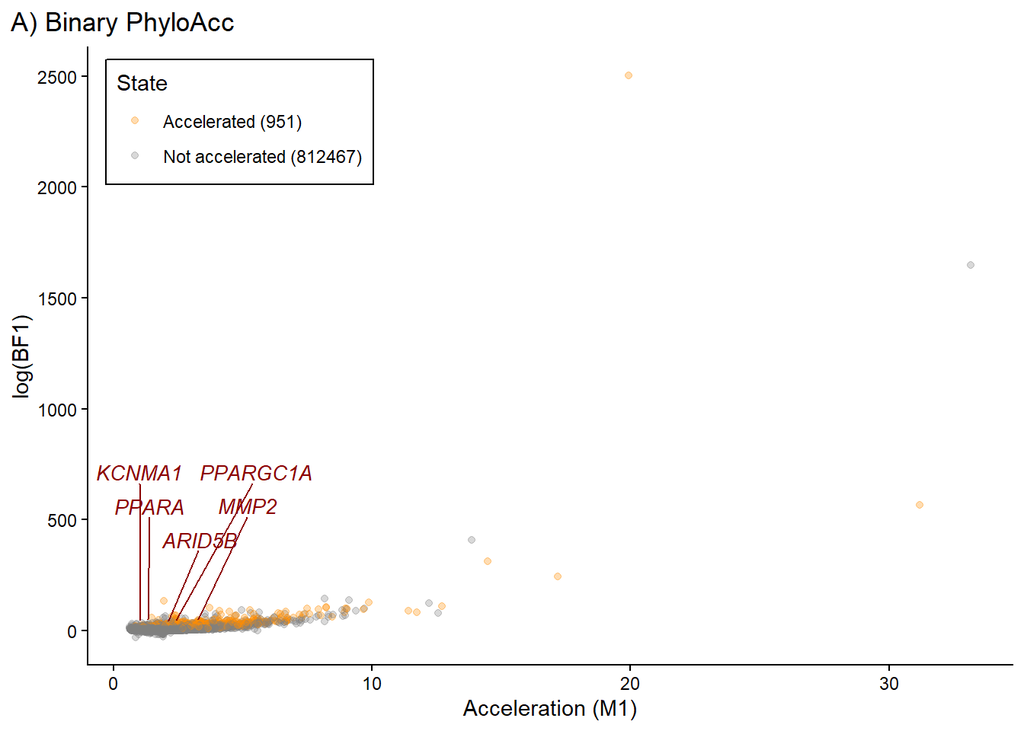

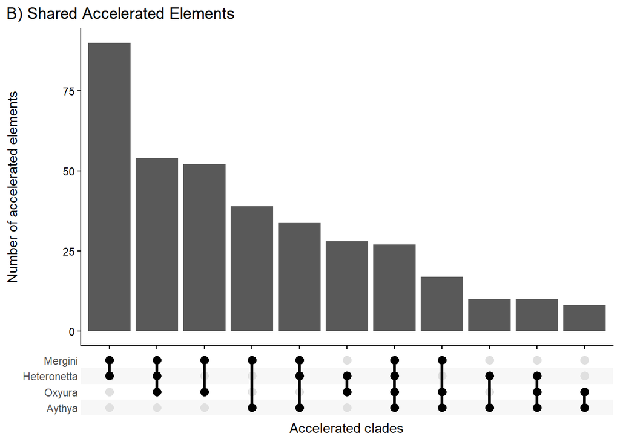

```r
accel_elements <- subset(accel_elements, n_clades >= 2)

phy2 <- ggplot(accel_elements, aes(x = clades)) +
  geom_bar() +
  scale_x_upset(order_by = "freq") +
  ggtitle("B) Shared Accelerated Elements") +
  labs(
    x = "Accelerated clades",
    y = "Number of accelerated elements"
  ) +
  theme_classic()+
  theme(
    plot.title.position = "plot",
    plot.title = element_text(hjust = 0)
  )
phy2
```

## 4.4 Continuous

We ran PhyloAcc-C model for PC1 of each of the four selected bones. To run PhyloAcc-C, we used the following code:

```r
library(coda)
library(parallel)
suppressMessages(library(sm))
library(argparse)
library(stringi)
library(ape)

ELL_do_mcmc = function(row_i) {
  mclapply(1:args$runs, function(i) {
    pac3::run_model(tree=tree, alignment=(all_alignments[[ row_i]]),
                    trait_tbl=trait_tbl,
                    transition_matrix=Q, stationary_distro=PI, n_iter=args$iter,
                    inner_iter=500,
                    Phi_prior=c(1.0, 1.0, 1.0, 1.0, 1.0, 1.0),
                    prior_r2=c(4,0.1),
                    prior_r3=c(10,0.4))
  }, mc.cores=1) # N.B. set to 1 = lapply, so do parallelism at element level
}

ELL_make_mcmclist = function(mcmc_outs, n_burnin=n_burnin, n_thin=1) {
  cs <- lapply(mcmc_outs, function(mcmc_out) {
    the_trace = with(mcmc_out$mcmc_trace,
                     data.frame(lv =v_trace[,1],
                                lb2=v_trace[,2],
                                lb3=v_trace[,3]))
    as.mcmc(the_trace, start=(n_burnin+1), thin=n_thin)
  })
  as.mcmc.list(cs)
}

do_ith_element = function(i) {
  print(paste("Working on element ",i," of ",length(all_alignments)," of batch ",ceiling(start_index/args$batch_size) , sep=""))
  the_mcmc_outs = ELL_do_mcmc(i)
  the_trace = do.call(rbind, lapply(1:args$runs, function(i) the_mcmc_outs[[i]]$mcmc_trace$v_trace[-(1:args$burnin),])) # needs the rbind otherwise don't get correct quantiles

  the_mcmc_list = ELL_make_mcmclist(the_mcmc_outs)
  rhat = gelman.diag(the_mcmc_list)$mpsrf

  the_density = sm.density(the_trace[,2:3], model="Normal", eval.grid=F, eval.points=matrix(data=c(0,0), byrow=T, nrow=1, ncol=2), display="none")
  the_density2= sm.density(the_trace[,3]-the_trace[,2], model="Normal", eval.grid=F, eval.points=0, display="none")

  qlv  = as.numeric(quantile(the_trace[,1], prob=c(.1,.5,.9)))
  qlb2 = as.numeric(quantile(the_trace[,2], prob=c(.1,.5,.9)))
  qlb3 = as.numeric(quantile(the_trace[,3], prob=c(.1,.5,.9)))
  qrat = as.numeric(quantile(the_trace[,3]- the_trace[,2], prob=c(.1,.5,.9)))
  list( lv.10=qlv [1],  lv.50=qlv [2],  lv.90=qlv [3],
        lb2.10=qlb2[1], lb2.50=qlb2[2], lb2.90=qlb2[3],
        lb3.10=qlb3[1], lb3.50=qlb3[2], lb3.90=qlb3[3],
        rat.10=qrat[1], rat.50=qrat[2], rat.90=qrat[3],
        rhat=as.numeric(rhat),
        dens0=as.numeric(the_density$estimate),
        densr=as.numeric(the_density2$estimate))
}

do_these_elements = function(indices) {
  mclapply(indices, function(i) {
    the_res = do_ith_element(i)
    the_res$NAME = names(all_alignments[i])
    the_res
  }, mc.cores=args$cores)
}

# Create Argument Parser
parser <- ArgumentParser(description = "Run PhyloAcc-c")

# Add arguments
parser$add_argument("--mod_file", type="character", help = "Path to mod file with tree and neutral rates")
parser$add_argument("--output", type="character", help = "Output file name")
parser$add_argument("--output_folder", default="./", type="character", help = "Output folder name (default = ./)")
parser$add_argument("--fasta", type="character", help = "Fasta folder")
parser$add_argument("--fasta_list", type="character", help = "Optional list to only include from fasta")
parser$add_argument("--traits", type="character", help = "Tab-delimited file with species and trait")
parser$add_argument("--batch_size", type="integer", default=100, help = "How many elements to run and write at one time")
parser$add_argument("--runs", type="integer", default=3, help = "Number of runs per element (default=3)")
parser$add_argument("--cores", type="integer", default=1, help = "How many cores to run in parallel")
parser$add_argument("--iter", type="integer", default=10000, help = "Number of iterations per element (default=10000)")
parser$add_argument("--burnin", type="integer", default=1000, help = "Number of iterations of burnin to discard (default=1000)")
parser$add_argument("--max_missing", type="double", default=0.5, help = "Fraction of taxa need to be present in alignment (default=0.5)")

# Parse arguments
args <- parser$parse_args()

print(args)
# Parse mod file
lines <- readLines(args$mod_file)

for (line_index in seq_along(lines)) {
  # Split the line by ":"
  parts <- stri_split_fixed(lines[line_index], ":", n=2)[[1]]

  # Extract variable name and IDs
  variable <- trimws(parts[1])  # Trim whitespace
  if (variable == "BACKGROUND") {
    PI <- as.numeric(unlist(strsplit(trimws(parts[2]), "\\s+")))
  }
  if (variable == "RATE_MAT"){
    mat_vals <- strsplit(lines[(line_index+1):(line_index+4)], "\\s+")
    Q <- do.call(rbind, mat_vals)
    Q <- Q[,-1]
    Q <- matrix(as.numeric(Q), nrow=4, byrow=F)
    line_index <- line_index + 4
  }
  if (variable == "TREE"){
    tree = read.tree(text = trimws(parts[2]))
    tree$node.label <- paste("Anc", 0:Nnode(tree), sep="")
  }
}

# Get trait data
trait_tbl <- read.table(args$traits)
colnames(trait_tbl) <- c("NAME", "Y")
tree <- keep.tip(tree, trait_tbl$NAME)

trait_tbl$NAME <- factor(trait_tbl$NAME, levels = tree$tip.label)
trait_tbl <- trait_tbl[order(trait_tbl$NAME),]
row.names(trait_tbl) <- 1:nrow(trait_tbl)

alignment_loc <- args$fasta
fasta_files <- list.files(alignment_loc, full.names = T, include.dirs = F)
fasta_basenames <- tools::file_path_sans_ext(basename(fasta_files))

if (!is.null(args$fasta_list)){
  keep_fasta <- read.table(args$fasta_list)
  fasta_files <- fasta_files[which(fasta_basenames %in% keep_fasta$V1)]
  fasta_basenames <- fasta_basenames[which(fasta_basenames %in% keep_fasta$V1)]
}

#some basic housekeeping
start_run <- T
if (!file.exists(args$output_folder)) {
  # If it doesn't exist, create the output folder
  dir.create(args$output_folder)
}

# Loop in batches of batch size
for (start_index in seq(1, length(fasta_files), by = args$batch_size)){
  all_alignments <- list()
  for (each_file in start_index:(start_index + args$batch_size - 1)){
    element <- fasta_basenames[each_file]
    alignment <- read.dna(fasta_files[each_file], format = "fasta", as.matrix = T, as.character = T)
    if ((nrow(alignment) > ((length(tree$tip.label))*args$max_missing))) {
        alignment <- alignment[rownames(alignment) %in% trait_tbl$NAME,]
        alignment[alignment=="*"] <- "-"
    alignment[alignment=="n"] <- "-"
        all_same <- all(apply(alignment, 2, function(x) length(unique(x))) == 1)
        missing_taxa <- setdiff(tree$tip.label, rownames(alignment))
        if (length(missing_taxa > 0)){
            for (miss in missing_taxa){
            missing_row <- matrix(rep("-", ncol(alignment)), nrow=1)
                rownames(missing_row) <- miss
                alignment <- rbind(alignment, missing_row)
            }
        }
        if (!all_same){
            all_alignments <- append(all_alignments, setNames(list(alignment), element))
        }
    }
  }
  if(length(all_alignments) > 0){
    system.time(yyy <- do_these_elements(1:length(all_alignments)))
    tbl_to_write = do.call(rbind, yyy)
    out_fn = paste(args$output_folder, "/", args$output, ".tsv", sep="")
    if (file.exists(out_fn) & start_run){
        write.table(tbl_to_write, out_fn, sep="\t", row.names=F, quote=F, col.names=T)
        start_run <- F
    }
    write.table(tbl_to_write, out_fn, sep="\t", row.names=F, quote=F, col.names=F, append=T)
  }
}
```

This script can then be run as such:

```bash
scaffold="NC_052572.1"

Rscript run_phyloaccc.r --mod_file ducks_4d_Z_non-conserved.mod --output ${scaffold} --output_folder phylo_out_carpometacarpus --trait duck_carpometacarpus_pc1.txt --fasta fasta/fasta_Z/${scaffold}/ --fasta_list bed_ranges/${scaffold}.txt --batch_size 200 --cores 40 --iter 10000 --burnin 1000
```

### 4.4.1 Parsing outputs

#### 4.4.1.1 Femur

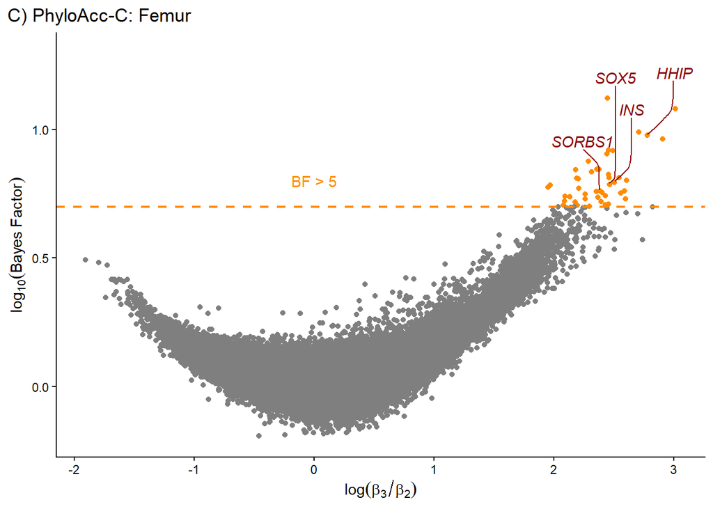

#### 4.4.1.2 Humerus

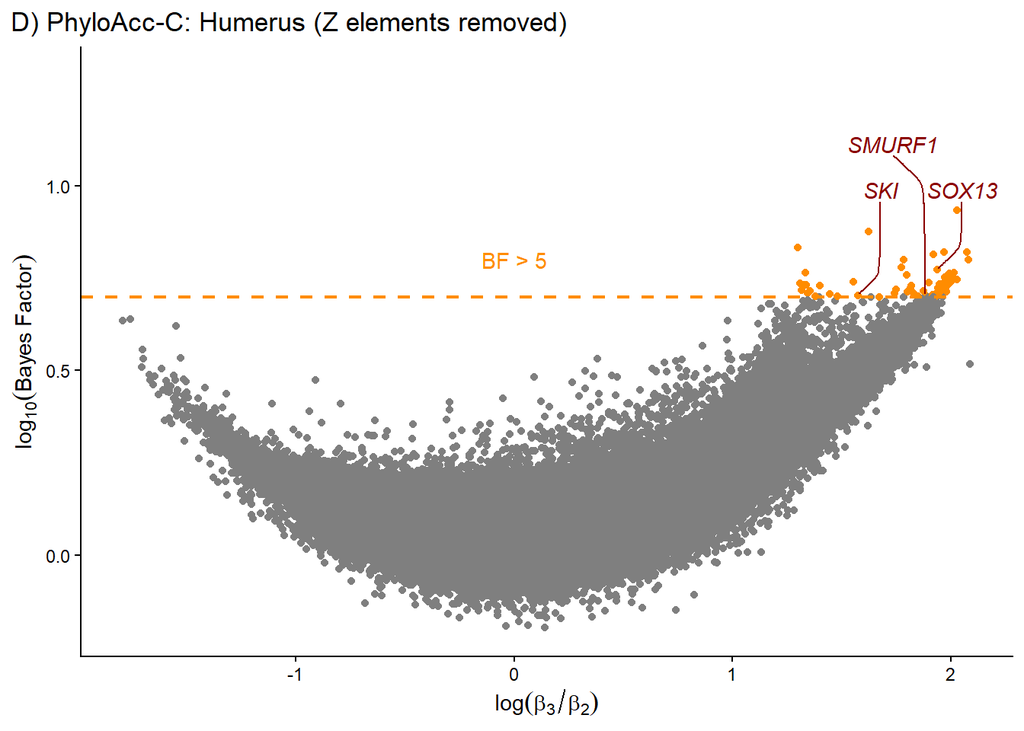

#### 4.4.1.3 Tarsometatarsus

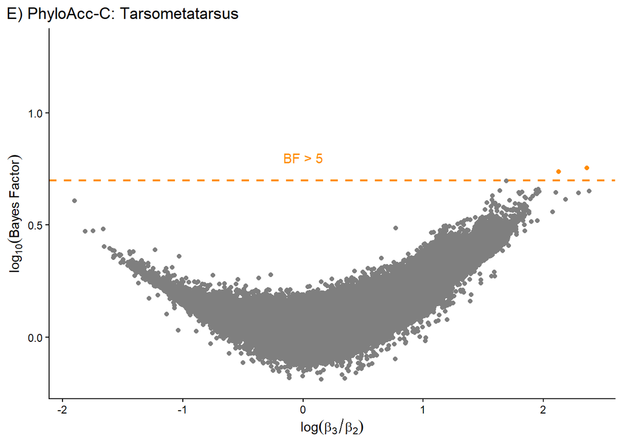

#### 4.4.1.4 Carpometacarpus

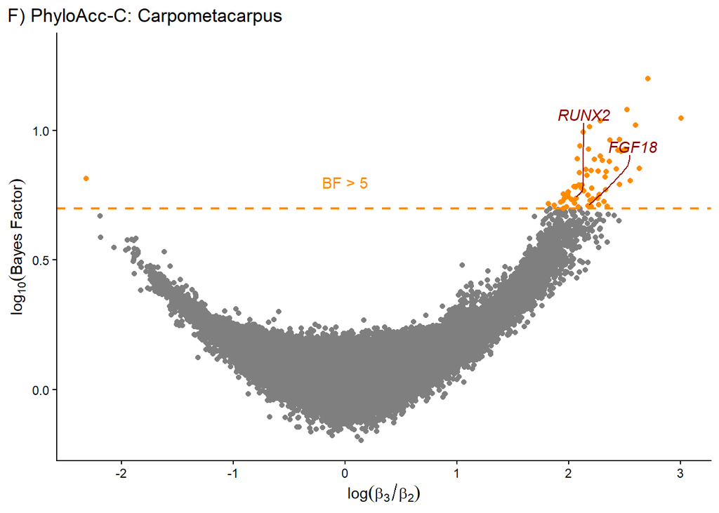

### 4.4.2 Individual runs

For highly significant loci, we can run phyloacc independently to generate more plots showing parameter mixing and trees with rates drawn on it. An Rdata file can also generated if you want to load that run. The code you can use is here:

```r
library(coda)
library(parallel)
suppressMessages(library(sm))
library(argparse)
library(stringi)
library(ape)
library(pac3)

# Create Argument Parser
parser <- ArgumentParser(description = "Run PhyloAcc-c")

# Add arguments
parser$add_argument("--mod_file", type="character", help = "Path to mod file with tree and neutral rates")
parser$add_argument("--fasta", type="character", help = "Fasta file")
parser$add_argument("--traits", type="character", help = "Tab-delimited file with species and trait")
parser$add_argument("--iter", type="integer", default=10000, help = "Number of iterations per element (default=10000)")
parser$add_argument("--burnin", type="integer", default=1000, help = "Number of iterations of burnin to discard (default=1000)")
parser$add_argument("--max_missing", type="double", default=0.5, help = "Fraction of taxa need to be present in alignment (default=0.5)")
parser$add_argument("--outfolder", type="character", default="./", help="output folder path")

# Parse arguments
args <- parser$parse_args()

# Parse mod file
lines <- readLines(args$mod_file)
trait_file <- args$traits
alignment_loc <- args$fasta

for (line_index in seq_along(lines)) {
  # Split the line by ":"
  parts <- stri_split_fixed(lines[line_index], ":", n=2)[[1]]

  # Extract variable name and IDs
  variable <- trimws(parts[1])  # Trim whitespace
  if (variable == "BACKGROUND") {
    PI <- as.numeric(unlist(strsplit(trimws(parts[2]), "\\s+")))
  }
  if (variable == "RATE_MAT"){
    mat_vals <- strsplit(lines[(line_index+1):(line_index+4)], "\\s+")
    Q <- do.call(rbind, mat_vals)
    Q <- Q[,-1]
    Q <- matrix(as.numeric(Q), nrow=4, byrow=F)
    line_index <- line_index + 4
  }
  if (variable == "TREE"){
    tree = read.tree(text = trimws(parts[2]))
    tree$node.label <- paste("Anc", 0:Nnode(tree), sep="")
  }
}

# Get trait data
trait_tbl <- read.table(trait_file)
colnames(trait_tbl) <- c("NAME", "Y")
tree <- keep.tip(tree, trait_tbl$NAME)

trait_tbl$NAME <- factor(trait_tbl$NAME, levels = tree$tip.label)
trait_tbl <- trait_tbl[order(trait_tbl$NAME),]
row.names(trait_tbl) <- 1:nrow(trait_tbl)

element <- tools::file_path_sans_ext(basename(alignment_loc))
alignment <- read.dna(alignment_loc, format = "fasta", as.matrix = T, as.character = T)
if ((nrow(alignment) > ((length(tree$tip.label))*args$max_missing))) {
  alignment <- alignment[rownames(alignment) %in% trait_tbl$NAME,]
  alignment[alignment=="*"] <- "-"
  alignment[alignment=="n"] <- "-"
  all_same <- all(apply(alignment, 2, function(x) length(unique(x))) == 1)
  missing_taxa <- setdiff(tree$tip.label, rownames(alignment))
  if (length(missing_taxa > 0)){
    for (miss in missing_taxa){
      missing_row <- matrix(rep("-", ncol(alignment)), nrow=1)
                rownames(missing_row) <- miss
                alignment <- rbind(alignment, missing_row)
                }
  }
}

save_model <- run_model(tree=tree, alignment=alignment,
                        trait_tbl=trait_tbl,
                        transition_matrix=Q, stationary_distro=PI, n_iter=args$iter,
                        inner_iter=500,
                        Phi_prior=c(1.0, 1.0, 1.0, 1.0, 1.0, 1.0),
                        #Phi_prior=c(2.0,1.0,1.0,50.0,1.0,1.0),
                        #prior_lv=c(0.0,3.0),
                        #prior_lb2=c(0,0.1),
                        #prior_lb3=c(0,0.1),
                        prior_r2=c(4,0.1),
                        #prior_r2=c(8,0.04),
                        prior_r3=c(10,0.4))

r_trace = save_model$mcmc_trace$r_trace
v_trace = save_model$mcmc_trace$v_trace

burnin = args$burnin

elem = strsplit(basename(args$fasta), "\\.")[[1]][1]

pdf(paste(args$outfolder, "/", elem, ".pdf", sep=""), paper="letter")
plot.new()
text(.1,.1, paste("sig^2", c("10%", "50%", "90%"), round(quantile(v_trace[-burnin,1], prob=c(.1,.5,.9)), 2), collapse = ";", sep = " "), pos=4, cex=0.75)
text(.1,.2, paste("B3:B2", c("10%", "50%", "90%"), round(quantile(v_trace[-burnin,3] - v_trace[-burnin,2], prob=c(.1,.5,.9)), 2), collapse = ";", sep=" "), pos=4, cex=0.75)
text(.1,.3, paste("r2", c("10%", "50%", "90%"), round(quantile(r_trace[-burnin,2], probs=c(.1,.5,.9)), 2), collapse = ";", sep=" "), pos=4, cex=0.75)
text(.1,.4, paste("r3", c("10%", "50%", "90%"), round(quantile(r_trace[-burnin,3], probs=c(.1,.5,.9)), 2), collapse = ";", sep=" "), pos=4, cex=0.75)
text(.1,.5, elem)
plot_z(save_model, drop_n = burnin)
plot_mixing(save_model, ith=100)
invisible(capture.output(dev.off()))
#save.image(file = paste(args$outfolder, "/", elem, ".rdata", sep=""))
```

## 4.5 Enrichment analysis

### 4.5.1 GO enrichment

```r
#Organism 9031 is Gallus gallus
#Dataset GO:0008150 is GO terms in biological processes group
accl_enrich <- rba_panther_enrich(genes = unique(closest_accl$gene),
                                 organism = 9031,
                                 annot_dataset = "GO:0008150")

accl_enrich <- rba_panther_enrich(genes = unique(genes_femur$gene),
                                 organism = 9031,
                                 annot_dataset = "GO:0008150")

accl_enrich <- rba_panther_enrich(genes = unique(genes_humerus$gene),
                                 organism = 9031,
                                 annot_dataset = "GO:0008150")

accl_enrich <- rba_panther_enrich(genes = unique(genes_tarso$gene),
                                 organism = 9031,
                                 annot_dataset = "GO:0008150")

accl_enrich <- rba_panther_enrich(genes = unique(genes_carpo$gene),
                                 organism = 9031,
                                 annot_dataset = "GO:0008150")

accl_enrich_table <- accl_enrich$result
```

GO enrichment by sampling

```r
nums <- 142 #number of accelerated CNEEs in for phyloacc-st
#nums <- 45 #for femur
#nums <- 67 #for humerus

enrich_out <- data.frame(term.id=character())
gene_out <- data.frame(term.id=character())
unique_genes <- c()
for (i in seq(1,1000)){
  rand_ces <- sample(all_data$id, nums)
  closest <- subset(closest_all, V4 %in% rand_ces)
  unique_genes <- c(unique_genes, length(unique(closest$gene)))
  enrich <- rba_panther_enrich(genes = unique(closest$gene),
                                   organism = 9031,
                                   annot_dataset = "GO:0008150")
  try({
    print(paste("Run", i, sep=" "))
    colnames(enrich$result)[1] <- paste(colnames(enrich$result)[1], i, sep = "_")
    colnames(enrich$result)[2] <- paste(colnames(enrich$result)[2], i, sep = "_")
    enrich_out <- merge(enrich_out, enrich$result[,c(paste("fold_enrichment",i, sep = "_"), "term.id")], by="term.id", all=T)
    gene_out <- merge(gene_out, enrich$result[,c(paste("number_in_list",i, sep = "_"), "term.id")], by="term.id", all=T)
  }, silent = T)
}


# Checkpoint directory
checkpoint_dir <- "panther_checkpoints"
dir.create(checkpoint_dir, showWarnings = FALSE)

for (i in seq(1, 1000)) {

  rand_ces <- sample(all_data$id, nums)
  closest <- subset(closest_all, V4 %in% rand_ces)
  unique_genes <- c(unique_genes, length(unique(closest$gene)))

  # Retry PANTHER up to 5 times
  max_retries <- 5
  attempt <- 1
  enrich <- NULL

  while (attempt <= max_retries && is.null(enrich)) {

    enrich <- tryCatch(
      rba_panther_enrich(
        genes = unique(closest$gene),
        organism = 9031,
        annot_dataset = "GO:0008150"
      ),
      error = function(e) {
        message(
          "Run ", i, ", attempt ", attempt,
          " failed: ", conditionMessage(e)
        )
        NULL
      }
    )

    if (is.null(enrich)) {
      attempt <- attempt + 1
      if (attempt <= max_retries) {
        Sys.sleep(5 * (attempt - 1))
      }
    }
  }

  if (!is.null(enrich)) {

    tryCatch({

      print(paste("Run", i))

      colnames(enrich$result)[1] <-
        paste(colnames(enrich$result)[1], i, sep = "_")
      colnames(enrich$result)[2] <-
        paste(colnames(enrich$result)[2], i, sep = "_")

      enrich_out <- merge(
        enrich_out,
        enrich$result[, c(
          paste("fold_enrichment", i, sep = "_"),
          "term.id"
        )],
        by = "term.id",
        all = TRUE
      )

      gene_out <- merge(
        gene_out,
        enrich$result[, c(
          paste("number_in_list", i, sep = "_"),
          "term.id"
        )],
        by = "term.id",
        all = TRUE
      )

    }, error = function(e) {
      message(
        "Error processing results for run ", i, ": ",
        conditionMessage(e)
      )
    })

  } else {
    message("Run ", i, " failed after ", max_retries, " attempts")
  }

  # Save checkpoint every 25 runs
  if (i %% 25 == 0) {

    checkpoint <- list(
      iteration = i,
      enrich_out = enrich_out,
      gene_out = gene_out,
      unique_genes = unique_genes
    )

    saveRDS(
      checkpoint,
      file = file.path(
        checkpoint_dir,
        paste0("checkpoint_", i, ".rds")
      )
    )

    message("Checkpoint saved after run ", i)
  }
}

# Save final results
saveRDS(
  list(
    iteration = 1000,
    enrich_out = enrich_out,
    gene_out = gene_out,
    unique_genes = unique_genes
  ),
  file = file.path(checkpoint_dir, "checkpoint_final.rds")
)


fwrite(enrich_out, paste("enrich_out_", nums, ".txt", sep=""), sep = "\t", col.names = T, row.names = F, quote = F)
fwrite(gene_out, paste("genes_out_", nums, ".txt", sep=""), sep = "\t", col.names = T, row.names = F, quote = F)
```

```r
gene_out <- fread("genes_out_142.txt", header=TRUE)

get_pgo <- function(GO, value, distr){

  if (GO %in% distr$term.id){

    vals <- as.numeric(distr[distr$term.id == GO, -1])
    vals <- vals[!is.na(vals)]

    return((sum(vals >= value)+1)/(length(vals)+1))

  } else {
    return(0)
  }
}

accl_enrich_table$pgo <- mapply(
  get_pgo,
  accl_enrich_table$term.id,
  accl_enrich_table$number_in_list,
  MoreArgs=list(distr=gene_out)
)

gene_out$median <- MatrixGenerics::rowMedians(as.matrix(gene_out[,2:ncol(gene_out)]), useNames = F)

accl_enrich_table <- merge(
  accl_enrich_table,
  gene_out[,c("term.id","median")],
  by="term.id",
  all.x=TRUE
)

tot <- median(unique_genes) # 125, 322

accl_enrich_table$median[accl_enrich_table$median == 0] <- 1e-5

accl_enrich_table$enrich <-
  (accl_enrich_table$number_in_list / 119) /
  (accl_enrich_table$median / 125)

accl_enrich_table$padj <- p.adjust(
  accl_enrich_table$pgo,
  method = "BH"
)

all_sigs <- subset(
  accl_enrich_table,
  padj < 0.05 &
  number_in_reference >= 5 &
  median >= 1
)

write.table(all_sigs, "GO_analysis_142.txt", row.names = F, col.names = T, sep = "\t", quote = F)
#write.table(all_sigs, "GO_analysis_femur.txt", row.names = F, col.names = T, sep = "\t", quote = F)
#write.table(all_sigs, "GO_analysis_humerus.txt", row.names = F, col.names = T, sep = "\t", quote = F)
#write.table(all_sigs, "GO_analysis_carpo.txt", row.names = F, col.names = T, sep = "\t", quote = F)
```

### 4.5.2 Generate skeletal set

The following python code was used to generte the skeletal element GO set

```python
import os
import csv
import gzip

HERE = os.path.dirname(os.path.abspath(__file__))
ROOT = os.path.dirname(HERE)
DATA = os.path.join(ROOT, "data")
RESULTS = os.path.join(ROOT, "results")

# ---- seed terms (high-level; DAG closure pulls in all descendants) ----------
# Two profiles are computed per gene:
#   is_skeletal        INCLUSIVE  (recall-oriented; skeleton-wide phenotype)
#   limb_appendicular  STRICT     (limb/appendicular skeleton only; precision)
# The inclusive flag is the default because skeleton-wide phenotype annotations
# are what catch genuine limb/skeletal genes (e.g. FGF18) whose mouse phenotype
# is recorded generically rather than as "limb bone". The strict flag lets the
# enrichment test be re-run as a sensitivity analysis (drops craniofacial-only
# genes such as BCAS3).

# Developmental GO processes (functional evidence; bone/cartilage/limb focused).
GO_SEEDS = {
    "GO:0001501": "skeletal system development",
    "GO:0060173": "limb development",
    "GO:0048736": "appendage development",
    "GO:0051216": "cartilage development",
    "GO:0060348": "bone development",
    "GO:0001503": "ossification",
    "GO:0001649": "osteoblast differentiation",
    "GO:0002062": "chondrocyte differentiation",
    "GO:0061448": "connective tissue development",
    "GO:0030509": "BMP signaling pathway",
}
# Inclusive (skeleton-wide + whole-limb) phenotype roots. MP nodes are the
# high-level system categories HMD actually uses.
MP_SEEDS = {
    "MP:0005390": "skeleton phenotype",
    "MP:0005371": "limbs/digits/tail phenotype",
}
HP_SEEDS = {
    "HP:0000924": "Abnormality of the skeletal system",
    "HP:0040064": "Abnormality of limbs",
}

# Strict limb/appendicular-skeleton subset (for the limb_appendicular sub-flag).
GO_LIMB = {
    "GO:0060173": "limb development",
    "GO:0048736": "appendage development",
}
# MGI is system-level (see header): the limb system category is the finest that
# matches HMD, and it correctly captures limb regulators like FGF18.
MP_LIMB = {"MP:0005371": "limbs/digits/tail phenotype"}
# HPO is term-level, so the limb tier can use bone-specific HPO nodes (keeping
# craniofacial-only genes such as BCAS3 out of the strict tier).
HP_LIMB = {
    "HP:0011844": "Abnormal appendicular skeleton morphology",
    "HP:0002813": "Abnormal limb bone morphology",
}


def load_obo_dag(path):
    """Return (alt2id, parents) where parents[id] = set of is_a/part_of targets."""
    alt2id, parents = {}, {}
    cur, obsolete = None, False
    op = gzip.open if path.endswith(".gz") else open
    with op(path, "rt") as fh:
        for line in fh:
            line = line.rstrip("\n")
            if line == "[Term]":
                cur, obsolete = None, False
            elif line.startswith("id: "):
                cur = line[4:].strip()
                parents.setdefault(cur, set())
            elif line.startswith("alt_id: ") and cur:
                alt2id[line[8:].strip()] = cur
            elif line.startswith("is_obsolete: true"):
                obsolete = True
                if cur:
                    parents.pop(cur, None)
                    cur = None
            elif cur and not obsolete and line.startswith("is_a: "):
                parents[cur].add(line[6:].split("!")[0].strip())
            elif cur and not obsolete and line.startswith("relationship: part_of "):
                parents[cur].add(line[len("relationship: part_of "):].split("!")[0].strip())
    return alt2id, parents


def closure(seeds, parents):
    """All terms that are the seeds or descend (is_a/part_of) from them."""
    children = {}
    for c, ps in parents.items():
        for p in ps:
            children.setdefault(p, set()).add(c)
    out, stack = set(seeds), list(seeds)
    while stack:
        t = stack.pop()
        for c in children.get(t, ()):
            if c not in out:
                out.add(c)
                stack.append(c)
    return out


def norm_terms(terms, alt2id):
    return {alt2id.get(t, t) for t in terms}


def load_chicken_go():
    """chicken GeneID -> set(GO)."""
    p = os.path.join(DATA, "GCF_016699485.2_gene_ontology.gaf.gz")
    d = {}
    with gzip.open(p, "rt") as fh:
        for line in fh:
            if line.startswith("!"):
                continue
            f = line.rstrip("\n").split("\t")
            if len(f) < 5:
                continue
            d.setdefault(f[1], set()).add(f[4])
    return d


def load_goa_human():
    """human SYMBOL(upper) -> set(GO)."""
    p = os.path.join(DATA, "goa_human.gaf.gz")
    d = {}
    with gzip.open(p, "rt") as fh:
        for line in fh:
            if line.startswith("!"):
                continue
            f = line.rstrip("\n").split("\t")
            if len(f) < 5:
                continue
            d.setdefault(f[2].upper(), set()).add(f[4])
    return d


def load_orthologs():
    """chicken GeneID -> human GeneID (NCBI gene_orthologs, hub=human 9606)."""
    p = os.path.join(DATA, "gene_orthologs.gz")
    c2h = {}
    with gzip.open(p, "rt") as fh:
        next(fh, None)
        for line in fh:
            f = line.rstrip("\n").split("\t")
            if len(f) < 5:
                continue
            tax, gid, _, otax, ogid = f[0], f[1], f[2], f[3], f[4]
            if tax == "9606" and otax == "9031":
                c2h[ogid] = gid
            elif otax == "9606" and tax == "9031":
                c2h[gid] = ogid
    return c2h


def load_gene_info(path, gz=True):
    """GeneID -> symbol ; symbol(upper) -> GeneID."""
    id2sym, sym2id = {}, {}
    op = gzip.open if gz else open
    with op(path, "rt") as fh:
        header = fh.readline().lstrip("#").rstrip("\n").split("\t")
        gi, si = header.index("GeneID"), header.index("Symbol")
        for line in fh:
            f = line.rstrip("\n").split("\t")
            id2sym[f[gi]] = f[si]
            sym2id[f[si].upper()] = f[gi]
    return id2sym, sym2id


def load_mgi_skeletal(mp_closure):
    """human symbols / GeneIDs whose mouse ortholog has a skeletal/limb MP."""
    p = os.path.join(DATA, "HMD_HumanPhenotype.rpt")
    syms, ids = set(), set()
    with open(p) as fh:
        for line in fh:
            f = line.rstrip("\n").split("\t")
            if len(f) < 5:
                continue
            hsym, hgid, mps = f[0], f[1], f[4]
            terms = {t.strip() for t in mps.split(",") if t.strip()}
            if terms & mp_closure:
                syms.add(hsym.upper())
                if hgid.isdigit():
                    ids.add(hgid)
    return syms, ids


def load_hpo_skeletal(hp_closure):
    """human GeneIDs / symbols with a skeletal/limb HPO annotation."""
    p = os.path.join(DATA, "genes_to_phenotype.txt")
    ids, syms = set(), set()
    with open(p) as fh:
        header = fh.readline().rstrip("\n").split("\t")
        gi = header.index("ncbi_gene_id"); si = header.index("gene_symbol"); hi = header.index("hpo_id")
        for line in fh:
            f = line.rstrip("\n").split("\t")
            if len(f) <= hi:
                continue
            if f[hi] in hp_closure:
                ids.add(f[gi]); syms.add(f[si].upper())
    return ids, syms




def gene_sources(gid, symU, hsym_eff, hgid_eff, chick_go, go_alt, go_c,
                 human_go, mgi_sym, mgi_id, hpo_id, hpo_sym):
    """Which evidence sources flag this gene under a given closure profile."""
    s = []
    if norm_terms(chick_go.get(gid, set()), go_alt) & go_c:
        s.append("chickenGO")
    if norm_terms(human_go.get(hsym_eff, set()), go_alt) & go_c:
        s.append("humanGO")
    if hsym_eff in mgi_sym or (hgid_eff and hgid_eff in mgi_id):
        s.append("MGI")
    if (hgid_eff and hgid_eff in hpo_id) or hsym_eff in hpo_sym:
        s.append("HPO")
    return s


def main():
    print("Building ontology DAG closures ...")
    go_alt, go_par = load_obo_dag(os.path.join(DATA, "go-basic.obo"))
    mp_alt, mp_par = load_obo_dag(os.path.join(DATA, "mp.obo"))
    hp_alt, hp_par = load_obo_dag(os.path.join(DATA, "hp.obo"))
    go_c = closure(GO_SEEDS, go_par); mp_c = closure(MP_SEEDS, mp_par); hp_c = closure(HP_SEEDS, hp_par)
    go_l = closure(GO_LIMB, go_par); mp_l = closure(MP_LIMB, mp_par); hp_l = closure(HP_LIMB, hp_par)
    print(f"  inclusive: GO {len(go_c)} MP {len(mp_c)} HP {len(hp_c)} | "
          f"limb: GO {len(go_l)} MP {len(mp_l)} HP {len(hp_l)}")

    print("Loading annotations ...")
    chick_go = load_chicken_go()
    human_go = load_goa_human()
    c2h = load_orthologs()
    h_id2sym, _ = load_gene_info(os.path.join(DATA, "Homo_sapiens.gene_info.gz"))
    chick_id2sym, _ = load_gene_info(os.path.join(DATA, "Gallus_gallus.gene_info.gz"))
    mgi_sym, mgi_id = load_mgi_skeletal(mp_c)      # inclusive
    hpo_id, hpo_sym = load_hpo_skeletal(hp_c)
    mgi_sym_l, mgi_id_l = load_mgi_skeletal(mp_l)   # limb-restricted
    hpo_id_l, hpo_sym_l = load_hpo_skeletal(hp_l)
    print(f"  chicken genes={len(chick_id2sym)} | chicken->human orthologs={len(c2h)}")

    out = os.path.join(RESULTS, "skeletal_genes.tsv")
    src_counts = {k: 0 for k in ("chickenGO", "humanGO", "MGI", "HPO")}
    n_skel = n_limb = 0
    with open(out, "w", newline="") as fh:
        w = csv.writer(fh, delimiter="\t")
        w.writerow(["chicken_gene_id", "chicken_symbol", "human_ortholog_symbol",
                    "is_skeletal", "sources", "limb_appendicular"])
        for gid, sym in sorted(chick_id2sym.items(), key=lambda x: x[1]):
            symU = sym.upper()
            hgid = c2h.get(gid)
            hsym = h_id2sym.get(hgid, "").upper() if hgid else ""
            hsym_eff = hsym or symU        # symbol fallback when no NCBI ortholog
            hgid_eff = hgid or ""
            sources = gene_sources(gid, symU, hsym_eff, hgid_eff, chick_go, go_alt,
                                   go_c, human_go, mgi_sym, mgi_id, hpo_id, hpo_sym)
            limb = gene_sources(gid, symU, hsym_eff, hgid_eff, chick_go, go_alt,
                                go_l, human_go, mgi_sym_l, mgi_id_l, hpo_id_l, hpo_sym_l)
            is_skel = bool(sources)
            if is_skel:
                n_skel += 1
                for s in sources:
                    src_counts[s] += 1
            if limb:
                n_limb += 1
            w.writerow([gid, sym, h_id2sym.get(hgid, "") if hgid else "",
                        int(is_skel), ";".join(sources), int(bool(limb))])
    print(f"\nWrote {out}")
    n = len(chick_id2sym)
    print(f"  is_skeletal (inclusive):    {n_skel}/{n} ({100*n_skel/n:.1f}%)")
    print(f"  limb_appendicular (strict): {n_limb}/{n} ({100*n_limb/n:.1f}%)")
    print("  inclusive by source (non-exclusive):", src_counts)

    print("\n  verification:")
    tsv = {r["chicken_symbol"]: r for r in csv.DictReader(open(out), delimiter="\t")}
    for g in ["IGF2", "SALL4", "SHOX", "RUNX2", "SOX5", "FGF18", "GLI3", "TBX5",
              "GDF5", "BCAS3", "INS", "CILP2", "GAPDH"]:
        r = tsv.get(g)
        if r:
            print(f"    {g:8s} skeletal={r['is_skeletal']} limb={r['limb_appendicular']} "
                  f"via={r['sources'] or '-'}")
        else:
            print(f"    {g:8s} (not in chicken gene_info)")


if __name__ == "__main__":
    main()
```

# References

Chatterji, Ray M, Tracy A Heath, Helen F James, Courtney A Hofman, Michael D Sorenson, and Janet C Buckner. 2026. “Dietary Specialization Drives Adaptation, Convergence, and Integration Across the Cranial and Appendicular Skeleton in Waterfowl (Anseriformes).” *Systematic Biology*, February, syag020. https://doi.org/10.1093/sysbio/syag020.

Porto, Arthur, Sara Rolfe, and A. Murat Maga. 2021. “ALPACA: A Fast and Accurate Computer Vision Approach for Automated Landmarking of Three-Dimensional Biological Structures.” *Methods in Ecology and Evolution* 12 (11): 2129–44. https://doi.org/https://doi.org/10.1111/2041-210X.13689.

Rolfe, Sara, Christopher Davis, and A. Murat Maga. 2021. “Comparing Semi-Landmarking Approaches for Analyzing Three-Dimensional Cranial Morphology.” *American Journal of Physical Anthropology* 175 (1): 227–37. https://doi.org/https://doi.org/10.1002/ajpa.24214.

Rolfe, Sara, Steve Pieper, Arthur Porto, et al. 2021. “SlicerMorph: An Open and Extensible Platform to Retrieve, Visualize and Analyse 3D Morphology.” *Methods in Ecology and Evolution* 12 (10): 1816–25. https://doi.org/https://doi.org/10.1111/2041-210X.13669.